# Machine Learning Process 2 (Logistic regresion)

> Rios Zambrano Angel

# Ejercicio 1

**El dataset de consumo_plantas.csv contienen datos que corresponden a 17 plantas electricas y el consumo de agua en galones que estas generan mensualmente.**

- **Y: Consumo de agua en galones.**
- **X1: Temperatura media mensual en grados Fahrenheit.**
- **X2: Producción mensual en libras.**
- **X3: Número de días de operación mensual.**
- **X4: Número de empleados.**
- **X5: No especificada.**

**Se pretende explicar el consumo de agua (Y) en función de las demas variables.**

> **a) Use el paquete statsmodels.api y ajuste un modelo de regresión lineal usando mínimos cuadrados (OLS) y muestre la tabla con el resumen del ajuste. ¿Qué observa en dicho ajuste?**

```python
import pandas as pd
import numpy as np
import statsmodels.api as sm

#cargamos la base
plants = pd.read_csv('data/consumo_plantas.csv')

features = ['X1','X2','X3','X4','X5']
keys = ['Y']
Y = plants.loc[:,keys].values
X = plants.loc[:,features].values

#Ajustamos el modelo
model = sm.OLS(Y, sm.add_constant(X)).fit()
model.summary()
```

OLS Regression Results

| Dep. Variable: | y | R-squared: | 0.820 |
| --- | --- | --- | --- |
| Model: | OLS | Adj. R-squared: | 0.738 |
| Method: | Least Squares | F-statistic: | 9.995 |
| Date: | Fri, 19 Jun 2020 | Prob (F-statistic): | 0.000834 |
| Time: | 08:48:42 | Log-Likelihood: | -112.78 |
| No. Observations: | 17 | AIC: | 237.6 |
| Df Residuals: | 11 | BIC: | 242.6 |
| Df Model: | 5 |  |  |
| Covariance Type: | nonrobust |  |  |

|  | coef | std err | t | P>\|t\| | [0.025 | 0.975] |
| --- | --- | --- | --- | --- | --- | --- |
| const | 7707.9134 | 1423.389 | 5.415 | 0.000 | 4575.056 | 1.08e+04 |
| x1 | 1.7859 | 8.249 | 0.217 | 0.833 | -16.370 | 19.941 |
| x2 | 0.2624 | 0.051 | 5.192 | 0.000 | 0.151 | 0.374 |
| x3 | -169.1652 | 50.110 | -3.376 | 0.006 | -279.458 | -58.873 |
| x4 | -9.7740 | 9.491 | -1.030 | 0.325 | -30.664 | 11.116 |
| x5 | -9.5434 | 5.331 | -1.790 | 0.101 | -21.276 | 2.189 |

| Omnibus: | 0.297 | Durbin-Watson: | 2.905 |
| --- | --- | --- | --- |
| Prob(Omnibus): | 0.862 | Jarque-Bera (JB): | 0.456 |
| Skew: | 0.006 | Prob(JB): | 0.796 |
| Kurtosis: | 2.198 | Cond. No. | 3.43e+05 |

Warnings:  
[1] Standard Errors assume that the covariance matrix of the errors is correctly specified.  
[2] The condition number is large, 3.43e+05. This might indicate that there are  
strong multicollinearity or other numerical problems.

$\therefore$ En primera instancia podemos notar que $R-squared=0.82$ y esto podría indicarnos que temos un excelento modelo, ya que se busca que este sea lo más cercano a $1$ sin embargo, si nos vamos a la tabla de coeficientes, podemos ver que el modelo incluye tres variables que no son significativas $X_1,X_4 \textit{ y } X_5$, entonces podríamos decir que lo que más influye en el consumo de agua en las plantas eléctricas es la $\textit{Producción mensual en libras}$ y el $\textit{Número de días de operación mensual}$

> **b) Estandarice los datos de las variables explicativas con escalador adecuado y posteriormente ajuste un modelo de componentes principales con 5 componentes. Calcule la varianza explicada acumulada por cada componente, muestre la matriz de transformación PCA. ¿Qué observa? ¿A qué cree que se deba dicho fenómeno? No use la variable a regersar (Y) para estandarizar ni en las componentes.**

```python
import matplotlib.pyplot as plt
import seaborn as sns
from sklearn.preprocessing import StandardScaler
from sklearn.decomposition import PCA

#Primero vamos a entandarizar la matriz
plants_est = StandardScaler(with_mean = True,with_std = True).fit_transform(X)

#Ajustamos el modelo de PCA
k = 5
PCA_Cols = ['pc' + str(i + 1) for i in range(0,k)]
PCA_model = PCA(n_components = k).fit(plants_est)
model_transf = pd.DataFrame(data = PCA_model.transform(plants_est),columns = PCA_Cols)

#Juntamos el modelo resultante a los datos originales
PCA_plants = pd.concat([plants,model_transf],axis = 1)
PCA_plants
```

|  | Planta | Y | X1 | X2 | X3 | X4 | X5 | pc1 | pc2 | pc3 | pc4 | pc5 |
| --- | --- | --- | --- | --- | --- | --- | --- | --- | --- | --- | --- | --- |
| 0 | 1 | 3067 | 58.8 | 7107 | 21 | 129 | 176.7 | 3.200976 | -1.202898 | -0.395657 | 0.562092 | -0.089517 |
| 1 | 2 | 2828 | 65.2 | 6373 | 22 | 141 | 157.6 | 3.364802 | -0.309641 | -0.508458 | 0.005754 | 0.218413 |
| 2 | 3 | 2891 | 70.9 | 6796 | 22 | 153 | 193.0 | 2.651303 | 0.025465 | -0.177932 | -0.366979 | -0.165731 |
| 3 | 4 | 2994 | 77.4 | 9208 | 20 | 166 | 212.6 | 1.685424 | -0.370732 | 1.276366 | -0.220461 | -0.003960 |
| 4 | 5 | 3082 | 79.3 | 14792 | 25 | 193 | 251.1 | -0.092919 | 2.672824 | -0.925997 | -0.117923 | 0.012409 |
| 5 | 6 | 3898 | 81.0 | 14564 | 23 | 189 | 232.3 | 0.190905 | 1.789655 | 0.168702 | 0.069756 | 0.309971 |
| 6 | 7 | 3502 | 71.9 | 11964 | 20 | 175 | 252.9 | 0.458841 | -0.461503 | 1.062354 | 0.050022 | -0.124368 |
| 7 | 8 | 3060 | 63.9 | 13526 | 23 | 186 | 260.7 | -0.137330 | 0.770500 | -0.787184 | -0.047961 | 0.066021 |
| 8 | 9 | 3211 | 54.5 | 12656 | 20 | 190 | 288.4 | -0.710203 | -1.232448 | 0.216068 | -0.248984 | 0.049167 |
| 9 | 10 | 3286 | 39.5 | 14119 | 20 | 187 | 325.2 | -1.507402 | -1.985029 | -0.578816 | 0.153720 | -0.180928 |
| 10 | 11 | 3542 | 44.5 | 16691 | 22 | 195 | 321.4 | -1.915830 | -0.511082 | -1.226333 | 0.374977 | 0.007706 |
| 11 | 12 | 3125 | 43.6 | 14571 | 19 | 206 | 320.6 | -2.021031 | -2.054935 | 0.251506 | -0.291239 | 0.325997 |
| 12 | 13 | 3022 | 56.0 | 13619 | 22 | 198 | 301.9 | -1.110656 | -0.089908 | -0.669399 | -0.400637 | -0.086922 |
| 13 | 14 | 2922 | 64.7 | 14575 | 22 | 192 | 290.5 | -0.848556 | 0.388111 | -0.213606 | -0.024913 | -0.142706 |
| 14 | 15 | 3950 | 73.0 | 14556 | 21 | 191 | 270.0 | -0.512855 | 0.359031 | 0.738723 | 0.048599 | 0.058343 |
| 15 | 16 | 4488 | 78.9 | 18573 | 21 | 200 | 294.4 | -1.594238 | 0.964800 | 1.162633 | 0.576518 | 0.052122 |
| 16 | 17 | 3295 | 79.4 | 15618 | 22 | 200 | 297.8 | -1.101231 | 1.247790 | 0.607029 | -0.122343 | -0.306018 |

A continuación se presenta la matriz de transformación de PCA y los $Eigenvalores$:

```python
PCA_Matrix = pd.DataFrame(PCA_model.components_.transpose(),columns = PCA_Cols)
display(PCA_Matrix)

#Eigenvalores
print(PCA_model.explained_variance_)
```

|  | pc1 | pc2 | pc3 | pc4 | pc5 |
| --- | --- | --- | --- | --- | --- |
| 0 | 0.188248 | 0.653083 | 0.679902 | -0.060210 | -0.268615 |
| 1 | -0.549779 | 0.248273 | 0.082817 | 0.749440 | 0.259970 |
| 2 | 0.071478 | 0.681751 | -0.718896 | -0.059771 | -0.098596 |
| 3 | -0.564651 | 0.182732 | 0.107221 | -0.647975 | 0.465199 |
| 4 | -0.581692 | -0.116906 | -0.050660 | -0.106161 | -0.796323 |

```
[3.01345131 1.5970691  0.58865758 0.08404473 0.02927728]
```

| Eigenvalores | 3.01345131 | 1.5970691 | 0.58865758 | 0.08404473 | 0.02927728 |
| --- | --- | --- | --- | --- | --- |

|  | explained variance |
| --- | --- |
| 0 | 0.567238 |
| 1 | 0.300625 |
| 2 | 0.110806 |
| 3 | 0.015820 |
| 4 | 0.005511 |

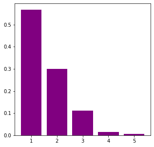

```python
def screePlot(plt,ratios):
    display(pd.DataFrame(ratios,columns=['explained variance']))
    plt.bar(list(range(1,len(ratios)+1)),ratios,color='purple')

plt.figure(figsize=(5,5))
screePlot(plt,PCA_model.explained_variance_ratio_)
```

$\therefore$ Con la gráfica podemos observar que posiblemente la cuarta y la quinta componente presenten colinealidad con otras variables, ya que estas aportan muy poca varianza al modelo.

> **c) Ajuste de nuevo un modelo de componentes principales con los datos estandarizados pero ahora con sólo las primeras q componentes que acumulen una varianza explicada igual superior al 85%, muestre la matriz de transformación PCA.**

```python
#Tomamos los datos que vamos a considerar
features = ['X1','X2','X3','X4']
keys = ['Y']
Y = plants.loc[:,keys].values
X_new = plants.loc[:,features].values

#Entandarizamos la matriz
plants_est_new = StandardScaler(with_mean = True,with_std = True).fit_transform(X_new)

#Ajustamos el modelo de PCA
k = 4
PCA_Cols_new = ['pc' + str(i + 1) for i in range(0,k)]
PCA_model_new = PCA(n_components = k).fit(plants_est_new)
model_transf_new = pd.DataFrame(data = PCA_model_new.transform(plants_est_new),columns = PCA_Cols_new)

#Mostramos el modelo
model_transf_new
```

|  | pc1 | pc2 | pc3 | pc4 |
| --- | --- | --- | --- | --- |
| 0 | 2.943573 | -0.439912 | -0.362658 | 0.573549 |
| 1 | 2.658969 | 0.367205 | -0.484180 | -0.018122 |
| 2 | 2.193978 | 0.644979 | -0.129703 | -0.336942 |
| 3 | 1.408979 | -0.020742 | 1.293608 | -0.214040 |
| 4 | -0.926047 | 2.506649 | -0.908751 | -0.117664 |
| 5 | -0.621768 | 1.617512 | 0.157955 | 0.029465 |
| 6 | 0.527786 | -0.332625 | 1.070686 | 0.067649 |
| 7 | -0.361405 | 0.697270 | -0.786454 | -0.056772 |
| 8 | -0.162165 | -1.311003 | 0.198928 | -0.255255 |
| 9 | -0.410728 | -2.109120 | -0.595509 | 0.171904 |
| 10 | -1.309258 | -0.860290 | -1.253492 | 0.365689 |
| 11 | -1.057003 | -2.431826 | 0.194376 | -0.337003 |
| 12 | -0.739860 | -0.256944 | -0.670964 | -0.388092 |
| 13 | -0.712583 | 0.232720 | -0.210477 | -0.007069 |
| 14 | -0.590154 | 0.188668 | 0.727944 | 0.040369 |
| 15 | -1.696291 | 0.497545 | 1.136080 | 0.563254 |
| 16 | -1.146022 | 1.009913 | 0.622612 | -0.080920 |

A continuación se presenta la matriz de transformación de PCA y los $Eigenvalores$:

```python
PCA_Matrix_new = pd.DataFrame(PCA_model_new.components_.transpose(),columns = PCA_Cols_new)
display(PCA_Matrix_new)

#Eigenvalores
print(PCA_model_new.explained_variance_)
```

|  | pc1 | pc2 | pc3 | pc4 |
| --- | --- | --- | --- | --- |
| 0 | 0.040121 | 0.708728 | 0.703985 | -0.022379 |
| 1 | -0.705029 | 0.011724 | 0.050861 | 0.707255 |
| 2 | -0.085383 | 0.703101 | -0.704438 | -0.046111 |
| 3 | -0.702876 | -0.056715 | 0.074740 | -0.705098 |

```
[2.05046632 1.53034341 0.58611236 0.08307791]
```

| Eigenvalores | 2.05046632 | 1.53034341 | 0.58611236 | 0.08307791 |
| --- | --- | --- | --- | --- |

> **d) Ajuste de nuevo un modelo de regresión lineal usando mínimos cuadrados pero ahora sobre las componentes principales y muestra la tabla con el resumen del nuevo ajuste ¿Qué diferencia observa en el nuevo ajuste respecto al primero?**

```python
features = ['pc1','pc2','pc3','pc4']
keys = ['Y']

Y = plants.loc[:,keys].values
X = model_transf_new.loc[:,features].values

#Ajustamos el modelo
model_new = sm.OLS(Y, sm.add_constant(X)).fit()
model_new.summary()
```

OLS Regression Results

| Dep. Variable: | y | R-squared: | 0.767 |
| --- | --- | --- | --- |
| Model: | OLS | Adj. R-squared: | 0.689 |
| Method: | Least Squares | F-statistic: | 9.877 |
| Date: | Fri, 19 Jun 2020 | Prob (F-statistic): | 0.000896 |
| Time: | 08:49:38 | Log-Likelihood: | -114.96 |
| No. Observations: | 17 | AIC: | 239.9 |
| Df Residuals: | 12 | BIC: | 244.1 |
| Df Model: | 4 |  |  |
| Covariance Type: | nonrobust |  |  |

|  | coef | std err | t | P>\|t\| | [0.025 | 0.975] |
| --- | --- | --- | --- | --- | --- | --- |
| const | 3303.7059 | 60.383 | 54.713 | 0.000 | 3172.143 | 3435.268 |
| x1 | -160.8070 | 43.466 | -3.700 | 0.003 | -255.511 | -66.103 |
| x2 | 37.3174 | 50.313 | 0.742 | 0.473 | -72.306 | 146.940 |
| x3 | 256.6597 | 81.299 | 3.157 | 0.008 | 79.524 | 433.795 |
| x4 | 844.7780 | 215.940 | 3.912 | 0.002 | 374.284 | 1315.272 |

| Omnibus: | 0.316 | Durbin-Watson: | 2.585 |
| --- | --- | --- | --- |
| Prob(Omnibus): | 0.854 | Jarque-Bera (JB): | 0.252 |
| Skew: | -0.245 | Prob(JB): | 0.882 |
| Kurtosis: | 2.660 | Cond. No. | 4.97 |

Warnings:  
[1] Standard Errors assume that the covariance matrix of the errors is correctly specified.

$\therefore$ A diferencia del primer ajuste, este presenta una sola variable no significativa, $p2$, lo que podría indicar que encontramos un modelo 'más completo', también podemos notar que tanto su $BIC$ como el $AIC$ son mayores en este modelo y que el $R-squared$ es más bajo, sin embargo la diferencia en estas medidas no es muy grande y podemos decir que este modelo es bueno ya que su varianza explicada es del $76.7\%$

> **e) Investigue y argumente como es que las componentes principales ayudan a mitigar el problema de la multicolinealidad severa.**

Al realizar este proceso se ayuda a reducir el problema de multicolinealidad, ya que estos modelos tienen como objetivo encontrar unas nuevas variables regresoras que, en este caso, son las componentes principales, estas se obtienen a partir de la matriz de observaciones donde los datos iniciales se transforman en otras variables independientes de tal forma que no esten correlacionadas, y con estas se ajusta la ecuación de regresión.

El argumento es el siguiente:

Partimos de la matriz de datos estandarizados $X^*$, se estima la matriz de correlación $R$, que corresponde a la matriz de correlación de los datos originales. $R$ se descompone $R = (L^*)^t \Lambda^* L^*$, sean $\lambda_1^*$, $\lambda_2^*$, ..., $\lambda_p^*$ los valores propios asociados a la matriz de correlación y $\Lambda^*$ la matriz diagonal de valores propios y $L^*$ la matriz ortogonal de vectores propios.

Posteriormente, se genera la matriz $Z_{n \times p}^* = X^*L^*$ que contiene las componentes principales y cada una de las columnas de $Z^*$ define el nuevo conjunto de variables predictoras ortogonales, donde $(Z^*)^t Z^* = (L^*)^t (X^*)^t X ^* L^* = I$

# Ejercicio 2

**El papel es manufacturado en láminas de gran tamaño antes de ser cortadas en hojas más pequeñas, se ha observado que la orientación de las fibras dentro del papel tiene diferentes efectos en la resistencia a la navaja en la máquina cortadora, dependiendo de la dirección en la que se corte la lámina. El dataset $paper.csv$ contiene mediciones de la resistencia en libras de varias láminas de papel que han sido cortadas en dirección a la máquina (Machine direction), en dirección opuesta a la máquina (Cross direction) además de la densidad en gramos sobre $cm^3$ de cada láminacortada (Density).**

> **a) Estandarice los datos de las variables explicativas con standar scaler con la opción de $with\_std = False$. Posteriormente ajuste modelo de componentes principales con 2 componentes. Calcule la varianza explicada acumulada por cada componente en forma de un scree plot, muestre la matriz de transformación PCA y grafique el biplot.**

```python
import pandas as pd
import numpy as np
from sklearn.preprocessing import StandardScaler
from sklearn.decomposition import PCA

#cargamos la base.
paper = pd.read_csv('data/paper.csv')

#Estandarizamos los datos con with_std=FALSE
paper_est = StandardScaler(with_mean = True,with_std = False).fit_transform(paper)

#Ajustamos un modelo PCA
k = 2
PCA_cols = ['pc' + str(i + 1) for i in range(0,k)]
PCA_model = PCA(n_components = k).fit(paper_est)
model_transf = pd.DataFrame(data = PCA_model.transform(paper_est),columns = PCA_cols)

#Juntamos el modelo resultante a los datos originales
PCA_paper = pd.concat([paper,model_transf],axis = 1)
PCA_paper.head()
```

|  | density | machine_direction | cross_direction | pc1 | pc2 |
| --- | --- | --- | --- | --- | --- |
| 0 | 0.821 | 121.41 | 70.42 | -2.241721 | -0.985542 |
| 1 | 0.824 | 127.70 | 72.47 | -7.634917 | 2.845905 |
| 2 | 0.841 | 129.20 | 78.20 | -13.131055 | 0.637823 |
| 3 | 0.816 | 131.80 | 74.89 | -12.020867 | 4.697836 |
| 4 | 0.840 | 135.10 | 71.21 | -11.030510 | 9.540508 |

A continuación se presenta la matriz de transformación de PCA y los $Eigenvalores$:

```python
PCA_Matrix1 = pd.DataFrame(PCA_model.components_.transpose(),columns = PCA_cols)
display(PCA_Matrix1)

#Eigenvalores
print(PCA_model.explained_variance_)
```

|  | pc1 | pc2 |
| --- | --- | --- |
| 0 | -0.001933 | -0.000096 |
| 1 | -0.595630 | 0.803258 |
| 2 | -0.803256 | -0.595631 |

```
[139.66437806  13.34778587]
```

| Eigenvalores | 139.66437806 | 13.34778587 |
| --- | --- | --- |

|  | explained variance |
| --- | --- |
| 0 | 0.912762 |
| 1 | 0.087233 |

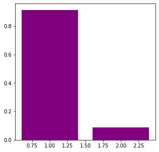

```python
import matplotlib.pyplot as plt

def screePlot(plt,ratios):
    display(pd.DataFrame(ratios,columns=['explained variance']))
    plt.bar(list(range(1,len(ratios)+1)),ratios,color='purple')

plt.figure(figsize=(5,5))
screePlot(plt,PCA_model.explained_variance_ratio_)
```

Y por último, graficamos el $Biplot$:

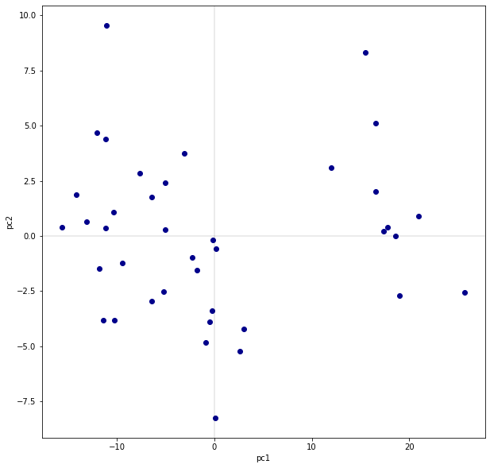

```python
def scatterPlot(plt,datasetPD,col_1,col_2,colorDots='darkblue',label=None,shift=0.05,**kwargs):
    dataPD = datasetPD[[col_1,col_2]]
    plt.scatter(dataPD[col_1],dataPD[col_2],color=colorDots)
    if(label!=None):
        points = datasetPD[[col_1,col_2,label]].values
        for point in points:
            plt.text(point[0]+shift,point[1]+shift,str(point[2]))
    plt.axvline(**kwargs)
    plt.axhline(**kwargs)

plt.figure(figsize=(10,10))
plt.xlabel('pc1')
plt.ylabel('pc2')
scatterPlot(plt,model_transf,'pc1','pc2','darkblue',color='Black',alpha=0.1)
plt.show()
```

> **b) Use el biplot para determinar el número k de grupos que hay dentro del dataset, posterior a esto aplique un algoritmo de mezclas gaussianas sobre los datos ya transformados con el PCA para impulsara cada registro la etiqueta del cluster correspondiente. Graficar el dendograma y la gráfica de siluetas.**

En el $Biplot$ anterior, es claro ver que existen dos grupos muy marcados dentro del data set.por lo tanto haremos la mezcla Gaussiana con $n\_components = 2$

|  | density | machine_direction | cross_direction | pc1 | pc2 | label_hat | scores |
| --- | --- | --- | --- | --- | --- | --- | --- |
| 0 | 0.821 | 121.41 | 70.42 | -2.241721 | -0.985542 | 0 | -5.255565 |
| 1 | 0.824 | 127.70 | 72.47 | -7.634917 | 2.845905 | 0 | -5.406742 |
| 2 | 0.841 | 129.20 | 78.20 | -13.131055 | 0.637823 | 0 | -5.854547 |
| 3 | 0.816 | 131.80 | 74.89 | -12.020867 | 4.697836 | 0 | -6.065124 |
| 4 | 0.840 | 135.10 | 71.21 | -11.030510 | 9.540508 | 0 | -9.039075 |

|  | density | machine_direction | cross_direction | pc1 | pc2 | label_hat | scores |
| --- | --- | --- | --- | --- | --- | --- | --- |
| 14 | 0.796 | 109.81 | 53.10 | 18.580039 | 0.013004 | 1 | -5.440550 |
| 15 | 0.759 | 109.10 | 50.68 | 20.946889 | 0.884122 | 1 | -5.813296 |
| 16 | 0.770 | 115.10 | 51.68 | 16.569828 | 5.108037 | 1 | -6.044832 |
| 17 | 0.759 | 118.31 | 50.60 | 15.525393 | 8.329778 | 1 | -7.962430 |
| 18 | 0.772 | 112.60 | 53.51 | 16.588942 | 2.009887 | 1 | -5.417308 |

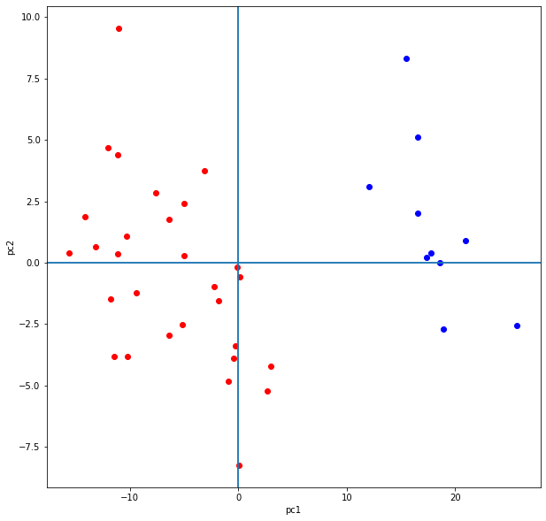

```python
from sklearn.mixture import GaussianMixture

features = ['pc1','pc2']

mixture_model_paper = GaussianMixture(n_components = 2)
mixture_model_paper.fit(PCA_paper[features])

PCA_paper['label_hat'] = mixture_model_paper.predict(PCA_paper[features])
PCA_paper['scores'] = mixture_model_paper.score_samples(PCA_paper[features])

display(PCA_paper[PCA_paper['label_hat']==0].head())
display(PCA_paper[PCA_paper['label_hat']==1].head())

plt.figure(figsize=(10,10))
plt.xlabel('pc1')
plt.ylabel('pc2')
scatterPlot(plt,PCA_paper[PCA_paper['label_hat']==0],'pc1','pc2','red')
scatterPlot(plt,PCA_paper[PCA_paper['label_hat']==1],'pc1','pc2','blue')
```

- **Dendograma**

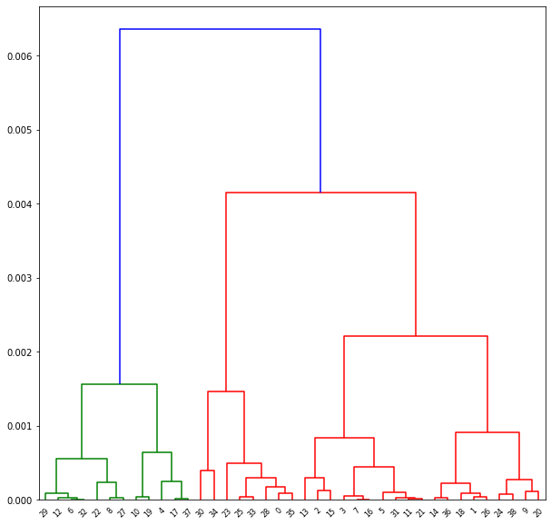

```python
from scipy.cluster import hierarchy

z = hierarchy.linkage(np.exp(PCA_paper[['scores']]), method='complete')

plt.figure(figsize=(10,10))
dn = hierarchy.dendrogram(z)
```

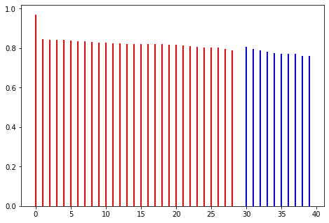

```python
import matplotlib.pyplot as plt
fig = plt.figure()
ax = fig.add_axes([0,0,1,1])

#Separamos las base de acuerdo al cluster al que pertenecen
PCA_0 = PCA_paper[PCA_paper['label_hat'] == 0]
PCA_1 = PCA_paper[PCA_paper['label_hat'] == 1]

#Ordenamos por densidad
PCA_1 = PCA_1.sort_values('density',ascending = False)
PCA_0 = PCA_0.sort_values('density',ascending = False)

#Extraemos la lista de densidad
DATOS1 =  PCA_1['density']
DATOS0 =  PCA_0['density']

cluster1 = np.arange(10)
cluster0 = np.arange(29)
ax.bar(cluster1+30,DATOS1,color = 'blue', width = 0.25)
ax.bar(cluster0,DATOS0,color = 'red', width = 0.25)

plt.show()
```

> **c) Utilizar el método de la envolvente elíptica para identificar las anomalías por cada grupo, use una confianza del 0.95. Utilizar el paquete de python $sklearn.covariance.EllipticEnvelope$ para realizar dicha tarea. Graficar las elipses de confianza por cada grupo.**

```python
#Separamos el dataset

##cluster-hat=0
cluster_0 = PCA_paper[PCA_paper['label_hat'] == 0][['pc1','pc2']]
#cluster-hat=1
cluster_1 = PCA_paper[PCA_paper['label_hat'] == 1][['pc1','pc2']]
```

- **Cluster_0**

```python
from sklearn.covariance import EllipticEnvelope

#Aplicamos el método de la envolvente elíptica
envol_eliptica = EllipticEnvelope(contamination = 0.05, random_state = 0).fit(cluster_0[:len(cluster_0)-1])
outliers = list(envol_eliptica.predict(cluster_0[:len(cluster_0)-1]))
outliers.append(1)

#Pegamos los resultados en la tabla original
cluster_0['outliers'] = outliers

#Outliers con 95% de confianza
cluster_0[cluster_0['outliers'] == -1]
```

|  | pc1 | pc2 | outliers |
| --- | --- | --- | --- |
| 4 | -11.03051 | 9.540508 | -1 |
| 8 | -11.41928 | -3.819570 | -1 |

$\Rightarrow$ Entonces para el primer Cluster, $Cluster\_0$,con el 95% de confianza tenemos solo dos outliers:

| pc1 | pc2 |
| --- | --- |
| -11.03051 | 9.540508 |
| -11.41928 | -3.819570 |

- **Cluster_1**

```python
#Aplicamos el método de la envolvente elíptica
envol_eliptica = EllipticEnvelope(contamination = 0.05, random_state = 0).fit(cluster_1[:len(cluster_1)-1])
outliers = list(envol_eliptica.predict(cluster_1[:len(cluster_1)-1]))
outliers.append(1)

#Pegamos los resultados en la tabla original
cluster_1['outliers'] = outliers
cluster_1[cluster_1['outliers'] == -1]
```

|  | pc1 | pc2 | outliers |
| --- | --- | --- | --- |
| 37 | 25.682136 | -2.563736 | -1 |

$\Rightarrow$ Entonces para el segundo Cluster, $Cluster\_1$,con el 95% de confianza tenemos un solo outlier:

| pc1 | pc2 |
| --- | --- |
| 25.682136 | -2.563736 |

Por último, graficaremos las elipses de confianza para cada grupo:

```python
from matplotlib.patches import Ellipse
from scipy.stats import chi2

#Definimos algunas funciones necesarias
def computeMaximumLikelihoodEstimators(datasetPD,columns):
    mu =  list(datasetPD[columns].mean())
    sigma = np.matrix(datasetPD[columns].cov())
    return mu, sigma

def diagonalize(sigma):
    eigenValues, eigenVectors = np.linalg.eigh(sigma)
    idx = eigenValues.argsort()[::-1]
    eigenValues = eigenValues[idx]
    eigenVectors = eigenVectors[:,idx]
    return eigenValues, eigenVectors

def plotConfidenceEllipse(plt,mu,eigenValues,eigenVectors,chiSquaredCriticalVale,ax=None,**kwargs):
    if ax is None:
        ax = plt.gca()
    theta = np.degrees(np.arctan2(*eigenVectors[:,0][::-1]))
    width,height = chiSquaredCriticalVale*np.sqrt(eigenValues)
    confidenceEllipse = Ellipse(xy=mu,width=width,height=height,angle=theta,**kwargs)
    ax.add_artist(confidenceEllipse)
    return confidenceEllipse

def getProbabilityDensityContour(plt,datasetPD,columns,alpha,freedomDegrees,color,name='DataSet'):
    mu, sigma = computeMaximumLikelihoodEstimators(datasetPD,columns)
    eigenValues, eigenVectors = diagonalize(sigma)
    chiSquaredCriticalVale = chi2.ppf(q=(1-alpha),df=freedomDegrees)
    plotConfidenceEllipse(plt,mu,eigenValues,eigenVectors,chiSquaredCriticalVale,color=color,alpha=0.25)
    sumaryTable=[]
    sumaryTable.append(['Mean',mu])
    sumaryTable.append(['Covariance matrix',sigma])
    sumaryTable.append(['EigenValues',eigenValues])
    sumaryTable.append(['EigenVectors',eigenVectors])
    sumaryTable.append(['Confidence',1-alpha])
    sumaryTable.append(['Chi-squared critical value',chiSquaredCriticalVale])
    sumaryTableDF = pd.DataFrame(sumaryTable,columns=['Summary',name])
    return sumaryTableDF
```

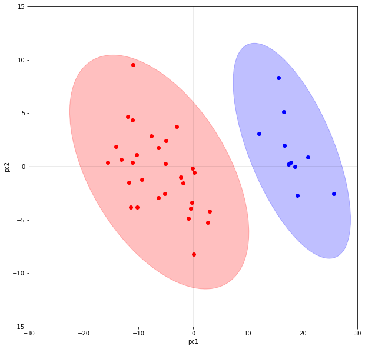

```python
cols = ['pc1','pc2']
alpha = 0.05
df = 2
plt.figure(figsize=(10,10))
plt.axis([-30,30,-15,15])
getProbabilityDensityContour(plt,cluster_0,cols,alpha,df,color = 'red')
scatterPlot(plt,cluster_0,'pc1','pc2','red',color = 'Black',alpha=0.05)
getProbabilityDensityContour(plt,cluster_1,cols,alpha,df,color = 'blue')
scatterPlot(plt,cluster_1,'pc1','pc2','blue',color='Black',alpha=0.05)
plt.xlabel('pc1')
plt.ylabel('pc2')
plt.show()
```

# Ejercicio 3

**Para el dataset del Cophasaurus texanus de la tarea 3 realizar el siguiente análisis:**

> **a) Ajustar un modelo de regresion logística sobre el espacio de características del dataset en $R^3$ (Mass, SVL y HLS). No olvide incluir el resumen del ajuste así como la tabla con la significancia de las variables. En este caso no es necesario hacer partición de train y test.**

```python
%matplotlib inline
import matplotlib.pyplot as plt
import pandas as pd
import seaborn as sns
import numpy as np
import math
import statsmodels.api as sm
from scipy.stats import norm
import warnings
import random
random.seed(500)
warnings.filterwarnings("ignore")
pd.set_option('max_colwidth',100)
plt.style.use('seaborn-paper')
plt.style.use('seaborn')
#cargamos la base de datos
lizard=pd.read_csv('data/Cophasaurus.csv')

###Ahora hacemos una variable dummy para el sexo
lizard['dummsex']=lizard.sexo.map({'f':1, 'm':0})
lizard.head()
```

|  | Lizard | Mass | SVL | HLS | sexo | dummsex |
| --- | --- | --- | --- | --- | --- | --- |
| 0 | 1 | 5.526 | 59.0 | 113.5 | f | 1 |
| 1 | 2 | 10.401 | 75.0 | 142.0 | m | 0 |
| 2 | 3 | 9.213 | 69.0 | 124.0 | f | 1 |
| 3 | 4 | 8.953 | 67.5 | 125.0 | f | 1 |
| 4 | 5 | 7.063 | 62.0 | 129.5 | m | 0 |

```python
#### Ahora ajustamos el modelo de regresión logística
import pandas as pd
from sklearn.linear_model import LogisticRegression

x=lizard[['Mass','SVL','HLS']]
y=lizard[['dummsex']]

log_model= LogisticRegression(random_state=1,penalty='l2').fit(x,y)

lizard['prob0'] = pd.DataFrame(log_model.predict_proba(x))[0]
lizard['prob1'] = pd.DataFrame(log_model.predict_proba(x))[1]
lizard['est_sex']= log_model.predict(x) ##estimación del modelo

lizard[['dummsex','prob0','prob1','est_sex']]
```

|  | dummsex | prob0 | prob1 | est_sex |
| --- | --- | --- | --- | --- |
| 0 | 1 | 1.613744e-05 | 9.999839e-01 | 1 |
| 1 | 0 | 9.999189e-01 | 8.114530e-05 | 0 |
| 2 | 1 | 7.689889e-03 | 9.923101e-01 | 1 |
| 3 | 1 | 2.904778e-02 | 9.709522e-01 | 1 |
| 4 | 0 | 9.072724e-01 | 9.272761e-02 | 0 |
| 5 | 1 | 2.946348e-02 | 9.705365e-01 | 1 |
| 6 | 0 | 9.996027e-01 | 3.972527e-04 | 0 |
| 7 | 1 | 2.611300e-10 | 1.000000e+00 | 1 |
| 8 | 0 | 1.000000e+00 | 6.027909e-11 | 0 |
| 9 | 1 | 6.904080e-02 | 9.309592e-01 | 1 |
| 10 | 0 | 9.961356e-01 | 3.864449e-03 | 0 |
| 11 | 1 | 2.814816e-05 | 9.999719e-01 | 1 |
| 12 | 0 | 9.962170e-01 | 3.782986e-03 | 0 |
| 13 | 0 | 9.939465e-01 | 6.053531e-03 | 0 |
| 14 | 0 | 9.852753e-01 | 1.472471e-02 | 0 |
| 15 | 0 | 9.977894e-01 | 2.210572e-03 | 0 |
| 16 | 1 | 3.614115e-04 | 9.996386e-01 | 1 |
| 17 | 0 | 9.890811e-01 | 1.091885e-02 | 0 |
| 18 | 0 | 9.999997e-01 | 2.675041e-07 | 0 |
| 19 | 0 | 9.948503e-01 | 5.149697e-03 | 0 |
| 20 | 1 | 1.359894e-04 | 9.998640e-01 | 1 |
| 21 | 1 | 4.221652e-03 | 9.957783e-01 | 1 |
| 22 | 0 | 9.997650e-01 | 2.350428e-04 | 0 |
| 23 | 1 | 3.743205e-05 | 9.999626e-01 | 1 |
| 24 | 1 | 1.030075e-04 | 9.998970e-01 | 1 |

La tabla de arriba nos muestra las probabilidades de cada lagartija de ser hembra o macho según el ajuste de una regresión logística; a continuación se presentan los coeficientes (las $\beta 's$) y el intercepto ($\beta_0$)

```python
coeficients = list(log_model.coef_[0][:2])
intercept = list(log_model.intercept_)

print('Coeficientes: ',coeficients)
print('Intercepto: ',intercept)
```

```
Coeficientes:  [0.09726584663171775, 0.28679455397351417]
Intercepto:  [95.19402403963717]
```

Ahora, haciendo un ajuste con la paquetería $\textit{statsmodels.api}$, notamos que la matriz de covarianzas no es invertible y que, para fines del ejercicio, era mejor trabajar solo con dos variables y quedarnos con el modelo que tuviera mejor $\textit{Pseudo R-square}$, a continuación presentamos una tabla con los $\textit{Pseudo R-square}$ de cada combinación:

| C1 | C2 | Pseudo R-square |
| --- | --- | --- |
| Mass | SVL | 0.4767 |
| SVL | HLS | 1.000 |
| Mass | HLS | $Error^*$ |

> $^*$ Para esta combinación la consola arroja un error de $\textit{Singular matrix}$, lo que indica que la matriz de covarianzas no es invertible.

De las otras dos combinaciones restantes, decidimos quedarnos con la primera ya que la segunda presentaba una $\textit{separación completa}$, esto quiere decir que no existe estimador máximo verosimil y que los parámetros no están bien identificados, lo que es perjudicial para el modelo.

```python
import numpy as np
from scipy.stats import norm
import statsmodels.api as sm

xx=lizard[['Mass','SVL']].values
yy=lizard[['dummsex']].values

#x2=lizard[['SVL','HLS']].values
#x3=lizard[['Mass','HLS']].values

l1_model = sm.Logit(yy, sm.add_constant(xx)).fit(disp=0)
l1_model.summary()
```

Logit Regression Results

| Dep. Variable: | y | No. Observations: | 25 |
| --- | --- | --- | --- |
| Model: | Logit | Df Residuals: | 22 |
| Method: | MLE | Df Model: | 2 |
| Date: | Fri, 19 Jun 2020 | Pseudo R-squ.: | 0.4767 |
| Time: | 08:50:46 | Log-Likelihood: | -9.0578 |
| converged: | True | LL-Null: | -17.309 |
| Covariance Type: | nonrobust | LLR p-value: | 0.0002610 |

|  | coef | std err | z | P>\|z\| | [0.025 | 0.975] |
| --- | --- | --- | --- | --- | --- | --- |
| const | 36.9477 | 18.870 | 1.958 | 0.050 | -0.037 | 73.932 |
| x1 | 0.6680 | 0.911 | 0.734 | 0.463 | -1.117 | 2.453 |
| x2 | -0.6258 | 0.375 | -1.668 | 0.095 | -1.361 | 0.110 |

> **b) Calcular y graficar la curva $ROC$, el $AUC$ y el ́índice de $GINI$ con base a los scores generados por el modelo logístico. Encuentre el threshold en los scores que cae en la rodilla de la curva $ROC$ y con dicho corte de probabilidad y los coeficientes ajustados encuentre la ecuación del plano separador (frontera de desicion).**

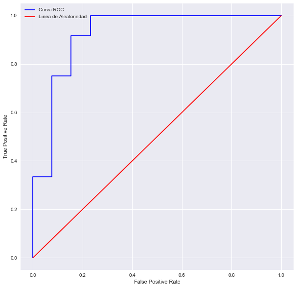

```
AUC: 0.923076923076923
GINI: 0.846153846153846
```

```python
from sklearn.metrics import roc_curve
from sklearn.metrics import roc_auc_score

test_X = lizard[['Mass','SVL']]
test_Y = lizard[['dummsex']]

lizard['score'] = l1_model.predict(sm.add_constant(test_X)).copy()


lizard_fpr, lizard_tpr, lizard_thresholds  = roc_curve(lizard['dummsex'],lizard['score'])

plt.figure(figsize=(10,10))
plt.plot(lizard_fpr,lizard_tpr, linestyle='-', color='blue', label='Curva ROC')
plt.plot([0,1],[0,1], color='red', label='Línea de Aleatoriedad')
plt.xlabel('False Positive Rate')
plt.ylabel('True Positive Rate')
plt.legend()
plt.show()

## AUC e índice de GINI
print('AUC:',roc_auc_score(lizard['dummsex'],lizard['score']))
print('GINI:',2*roc_auc_score(lizard['dummsex'],lizard['score'])-1)
```

Una vez que tenemos el $AUC$ y el índice de $GINI$, para obtener el $\textit{Cutoff}$, rotamos la gráfica $45°$ y el punto de corte será donde el $TPR$ alcance su máximo.

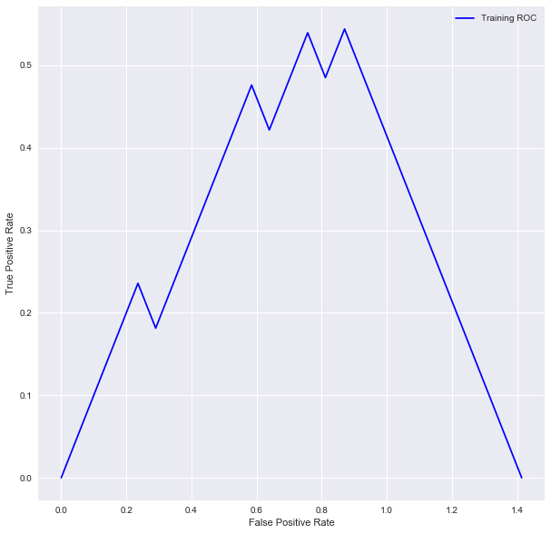

```
TPR : 1.0
FPR : 0.23076923076923078
```

```python
new_lizard_tpr = [0,0,0,0,0,0,0,0,0,0]
new_lizard_fpr = [0,0,0,0,0,0,0,0,0,0]


for i in range(0,len(lizard_tpr)):
    new_lizard_tpr[i]=(lizard_tpr[i]-lizard_fpr[i])*(1/pow(2,1/2))
    new_lizard_fpr[i]=(lizard_tpr[i]+lizard_fpr[i])*(1/pow(2,1/2))

plt.figure(figsize=(10,10))
plt.plot(new_lizard_fpr,new_lizard_tpr, linestyle='-', color='blue', label='Training ROC')
plt.xlabel('False Positive Rate')
plt.ylabel('True Positive Rate')
plt.legend()
plt.show()


indice=new_lizard_tpr.index(max(new_lizard_tpr))

TPR = lizard_tpr[indice]
threshold_cutoff = lizard_fpr[indice]


print("TPR :",TPR)
print("FPR :",threshold_cutoff)
```

Finalmente tenemos que:

[output not shown]

Ahora, para encontrar la ecuación de la recta de separación ($\textit{frontera de decisión}$), recordemos que para dos variables, se tiene que:

$$ ln\left(\frac{p(\mathbf{x})}{1-p(\mathbf{x})}\right) = \beta_0+\beta_1 x_1 +\beta_2 x_2 \quad \quad donde:$$

[output not shown]

> **c) Grafique en $R^3$ un scatter de los datos usando diferentes marcadores para hembras y machos. Luego en el mismo plot grafique el plano separador.**

Como para el ajuste de la regresión logística solo usamos dos variables, graficaremos un $\textit{scatter en }R^2$ y el plano será una recta.

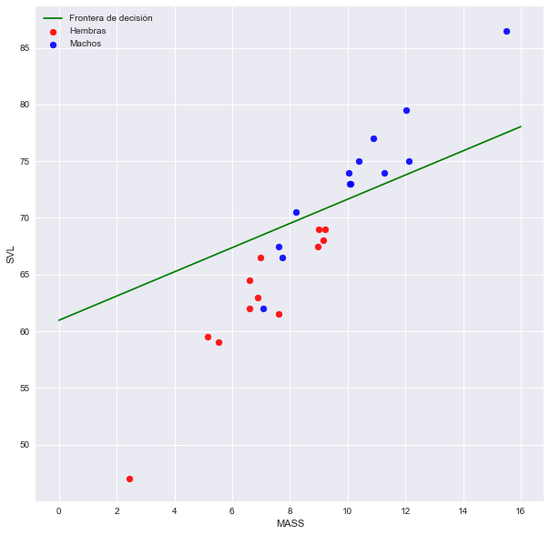

```python
#separamos el data set

##Hembras
lizard_h=lizard[lizard['dummsex']==1]
##Machos
lizard_m=lizard[lizard['dummsex']==0]

##sacamos de cada uno 'mass' y 'svl'

hem_m=lizard_h[['Mass']]
hem_s=lizard_h[['SVL']]

mac_m=lizard_m[['Mass']]
mac_s=lizard_m[['SVL']]

xh=hem_m
yh=hem_s

xm=mac_m
ym=mac_s


odds = np.log(threshold_cutoff/(1-threshold_cutoff))
# odds = b0_b1x1+b2x2

beta_0 = l1_model.params[0]
beta_1 = l1_model.params[1]
beta_2 = l1_model.params[2]
x1 = np.linspace(0, 16, 1000)
x2 = (odds-beta_0-beta_1*x1)*(1/beta_2)


plt.figure(figsize=(10,10))
plt.scatter(xh, yh, c='red', alpha=0.9,label='Hembras')
plt.scatter(xm, ym, c='blue', alpha=0.9, label='Machos')
plt.plot(x1, x2,color='green',alpha=1, label='Frontera de decisión') ##recta
plt.xlabel('MASS')
plt.ylabel('SVL')
plt.legend()
plt.show()
```

> **d) Con el mismo corte calcular la matriz de confusión, Precisión, Recall, Odds Ratio, F-Score con beta=1.**

```python
from sklearn.metrics import confusion_matrix, precision_score, recall_score, fbeta_score

precision = precision_score(lizard['dummsex'],lizard['est_sex'])
recall = recall_score(lizard['dummsex'],lizard['est_sex'])
cm=confusion_matrix(lizard['dummsex'],lizard['est_sex'])

print('Presición:',precision)
print('Recall:',recall)
print('Matriz de confusión:')
print(cm)
```

```
Presición: 1.0
Recall: 1.0
Matriz de confusión:
[[13  0]
 [ 0 12]]
```

- **Matriz de confusión**

[output not shown]

Ahora vamos a calcular los parámetros restantes

- **Odds Ratio**

$$DOR_c = \frac{TPR_c TNR_c }{ FPR_c FNR_c}=\frac{\left(0.75\right)\left(0.9\right)}{\left(0.07692\right)\left(0.25\right)}=35.10140$$

> Fall out:
> $$FPR_c = \frac{FP_c}{FP_C+TN_c}=\frac{1}{1+12}=\frac{1}{13}=0.07692$$ Miss Rate: $$FNR_c = \frac{FN_c}{FN_c+TP}=\frac{3}{3+9}=\frac{1}{4}=0.25$$

Finalmente obtenemos:

- **Matriz de confusión**

[output not shown]

> En términos de probabilidades la matriz de confusión queda de la siguiente forma:

|  | 0.pred | 1.pred |
| --- | --- | --- |
| 0 | 48% | 4% |
| 1 | 12% | 36% |

[output not shown]

# Ejercicio 4

**Para el dataset del titanic de la tarea 3 realizar el siguiente analisis:**

> **a) Separar el dataset en train y test (50% y 50%), imputar variables continuas y dicretas. Estandarizar y centrar las variables continuas y ajustar un OneHotEncondig a las variables categoricas. Recuerde no usar test para los imputadores, escaladores ni el OHE.**

```python
run MvaUtils.py
```

```python
%matplotlib inline
import pandas as pd
import matplotlib.pyplot as plt
import numpy as np
import math
import statsmodels.api as sm
import numpy as np
from sklearn.model_selection import train_test_split
from scipy.stats import norm
import warnings
import seaborn as sns
import random
random.seed(500)
warnings.filterwarnings("ignore")
pd.set_option('max_colwidth',100)
plt.style.use('seaborn-paper')
plt.style.use('seaborn')


pd.set_option('max_row',6)
plt.style.use('ggplot')

#cargamos la base de datos
titanic=pd.read_csv('data/Titanic.csv')
df=titanic
df['ID']=list(range(1,1309))
df
```

|  | survived | pclass | sex_numeric | embarked_numeric | cabin_numeric | sibsp | parch | fare | age | ID |
| --- | --- | --- | --- | --- | --- | --- | --- | --- | --- | --- |
| 0 | 1 | 1 | 1 | 0 | 2 | 0 | 0 | 211.3375 | 29.0000 | 1 |
| 1 | 1 | 1 | 0 | 0 | 3 | 1 | 2 | 151.5500 | 0.9167 | 2 |
| 2 | 0 | 1 | 1 | 0 | 3 | 1 | 2 | 151.5500 | 2.0000 | 3 |
| ... | ... | ... | ... | ... | ... | ... | ... | ... | ... | ... |
| 1305 | 0 | 3 | 0 | 3 | 8 | 0 | 0 | 7.2250 | 26.5000 | 1306 |
| 1306 | 0 | 3 | 0 | 3 | 8 | 0 | 0 | 7.2250 | 27.0000 | 1307 |
| 1307 | 0 | 3 | 0 | 0 | 8 | 0 | 0 | 7.8750 | 29.0000 | 1308 |

1308 rows × 10 columns

```python
from sklearn.model_selection import train_test_split
import pandas as pd
import numpy as np
import seaborn as sns
import matplotlib.pyplot as plt
plt.style.use('ggplot')
%matplotlib inline

def compute_frequencies(dataset_df,col,index=None):
    if index is None:
        index = 'index'
    columns=[col,'freqs_'+col,'relative_freqs_'+col]
    freqs_df = dataset_df.reset_index()\
                .groupby(col)\
                .count()\
                .reset_index()[[index,col]]\
                .rename(columns={index:'freqs_'+col})

    freqs_df['relative_freqs_'+col] = freqs_df['freqs_'+col]/len(df)
    freqs_df= freqs_df[columns].sort_values(col)
    missings_counts = df[col].isna().sum()
    missings_df = pd.DataFrame([['Missings',missings_counts,missings_counts/len(df)]],columns=columns)
    freqs_df = pd.concat([freqs_df, missings_df])
    return freqs_df
```

```python
numericals=['fare','age']
categoricals = ['pclass','sex_numeric','embarked_numeric','cabin_numeric','sibsp']
map_dictionary = {}
for col in categoricals:
    freqs_df = compute_frequencies(df,col,index='ID')
    display(freqs_df)
    colum_values = list(freqs_df[col])[:len(freqs_df)-1]
    column_dict = {}
    for i,value in enumerate(colum_values):
        column_dict.update({value:str(int(i))})
    column_dict.update({np.nan:np.nan})
    map_dictionary.update({col:column_dict})
Titanic_cleaned_df = df.replace(map_dictionary).copy()
Titanic_cleaned_df
```

|  | pclass | freqs_pclass | relative_freqs_pclass |
| --- | --- | --- | --- |
| 0 | 1 | 322 | 0.246177 |
| 1 | 2 | 277 | 0.211774 |
| 2 | 3 | 709 | 0.542049 |
| 0 | Missings | 0 | 0.000000 |

|  | sex_numeric | freqs_sex_numeric | relative_freqs_sex_numeric |
| --- | --- | --- | --- |
| 0 | 0 | 842 | 0.643731 |
| 1 | 1 | 466 | 0.356269 |
| 0 | Missings | 0 | 0.000000 |

|  | embarked_numeric | freqs_embarked_numeric | relative_freqs_embarked_numeric |
| --- | --- | --- | --- |
| 0 | 0 | 1038 | 0.793578 |
| 1 | 3 | 270 | 0.206422 |
| 0 | Missings | 0 | 0.000000 |

|  | cabin_numeric | freqs_cabin_numeric | relative_freqs_cabin_numeric |
| --- | --- | --- | --- |
| 0 | 1 | 22 | 0.016820 |
| 1 | 2 | 65 | 0.049694 |
| 2 | 3 | 94 | 0.071865 |
| ... | ... | ... | ... |
| 6 | 7 | 5 | 0.003823 |
| 7 | 8 | 1014 | 0.775229 |
| 0 | Missings | 0 | 0.000000 |

9 rows × 3 columns

|  | sibsp | freqs_sibsp | relative_freqs_sibsp |
| --- | --- | --- | --- |
| 0 | 0 | 890 | 0.680428 |
| 1 | 1 | 319 | 0.243884 |
| 2 | 2 | 42 | 0.032110 |
| ... | ... | ... | ... |
| 5 | 5 | 6 | 0.004587 |
| 6 | 8 | 9 | 0.006881 |
| 0 | Missings | 0 | 0.000000 |

8 rows × 3 columns

|  | survived | pclass | sex_numeric | embarked_numeric | cabin_numeric | sibsp | parch | fare | age | ID |
| --- | --- | --- | --- | --- | --- | --- | --- | --- | --- | --- |
| 0 | 1 | 0 | 1 | 0 | 1 | 0 | 0 | 211.3375 | 29.0000 | 1 |
| 1 | 1 | 0 | 0 | 0 | 2 | 1 | 2 | 151.5500 | 0.9167 | 2 |
| 2 | 0 | 0 | 1 | 0 | 2 | 1 | 2 | 151.5500 | 2.0000 | 3 |
| ... | ... | ... | ... | ... | ... | ... | ... | ... | ... | ... |
| 1305 | 0 | 2 | 0 | 1 | 7 | 0 | 0 | 7.2250 | 26.5000 | 1306 |
| 1306 | 0 | 2 | 0 | 1 | 7 | 0 | 0 | 7.2250 | 27.0000 | 1307 |
| 1307 | 0 | 2 | 0 | 0 | 7 | 0 | 0 | 7.8750 | 29.0000 | 1308 |

1308 rows × 10 columns

```python
train_df, test_df = train_test_split(Titanic_cleaned_df, test_size=0.5)
```

```python
train_df
```

|  | survived | pclass | sex_numeric | embarked_numeric | cabin_numeric | sibsp | parch | fare | age | ID |
| --- | --- | --- | --- | --- | --- | --- | --- | --- | --- | --- |
| 494 | 0 | 1 | 0 | 1 | 7 | 0 | 0 | 15.5792 | 0.385027 | 495 |
| 1046 | 1 | 2 | 1 | 1 | 7 | 0 | 0 | 7.2250 | 15.000000 | 1047 |
| 523 | 1 | 1 | 0 | 1 | 7 | 0 | 0 | 13.8625 | 0.385027 | 524 |
| ... | ... | ... | ... | ... | ... | ... | ... | ... | ... | ... |
| 229 | 1 | 0 | 1 | 0 | 1 | 0 | 0 | 93.5000 | 30.000000 | 230 |
| 358 | 1 | 1 | 0 | 0 | 7 | 0 | 2 | 29.0000 | 0.833300 | 359 |
| 1034 | 1 | 2 | 0 | 1 | 7 | 1 | 1 | 15.2458 | 0.385027 | 1035 |

654 rows × 10 columns

No se imputaran valores ya que ninguna de las variables cuenta con Missing Values

### Estandarizacion

```python
from sklearn.preprocessing import StandardScaler

standard_scaler = StandardScaler().fit(train_df[numericals])
std_data_matrix_train = standard_scaler.transform(train_df[numericals])
std_data_matrix_train

std_data_matrix_train = pd.DataFrame(std_data_matrix_train,columns=numericals)
std_data_matrix_train['ID'] = train_df.index
std_data_matrix_train.set_index('ID',inplace=True)
std_data_matrix_train
```

| ID | fare | age |
| --- | --- | --- |
| 494 | -0.290272 | -1.339703 |
| 1046 | -0.438347 | -0.503164 |
| 523 | -0.320700 | -1.339703 |
| ... | ... | ... |
| 229 | 1.090839 | 0.355414 |
| 358 | -0.052395 | -1.314044 |
| 1034 | -0.296182 | -1.339703 |

654 rows × 2 columns

### OneHotEncoding

```python
from sklearn.preprocessing import OneHotEncoder

one_hot_encoder = OneHotEncoder(sparse=False).fit(train_df[categoricals])
dummy_matrix_train_df = pd.DataFrame(one_hot_encoder.transform(train_df[categoricals]),
                                      columns=list(one_hot_encoder.get_feature_names(categoricals)))

dummy_columns = list(one_hot_encoder.get_feature_names(categoricals))
dummy_matrix_train_df['ID'] = train_df.index
dummy_matrix_train_df.set_index('ID',inplace=True)
dummy_matrix_train_df
```

| ID | pclass_0 | pclass_1 | pclass_2 | sex_numeric_0 | sex_numeric_1 | embarked_numeric_0 | embarked_numeric_1 | cabin_numeric_0 | cabin_numeric_1 | cabin_numeric_2 | ... | cabin_numeric_5 | cabin_numeric_6 | cabin_numeric_7 | sibsp_0 | sibsp_1 | sibsp_2 | sibsp_3 | sibsp_4 | sibsp_5 | sibsp_6 |
| --- | --- | --- | --- | --- | --- | --- | --- | --- | --- | --- | --- | --- | --- | --- | --- | --- | --- | --- | --- | --- | --- |
| 494 | 0.0 | 1.0 | 0.0 | 1.0 | 0.0 | 0.0 | 1.0 | 0.0 | 0.0 | 0.0 | ... | 0.0 | 0.0 | 1.0 | 1.0 | 0.0 | 0.0 | 0.0 | 0.0 | 0.0 | 0.0 |
| 1046 | 0.0 | 0.0 | 1.0 | 0.0 | 1.0 | 0.0 | 1.0 | 0.0 | 0.0 | 0.0 | ... | 0.0 | 0.0 | 1.0 | 1.0 | 0.0 | 0.0 | 0.0 | 0.0 | 0.0 | 0.0 |
| 523 | 0.0 | 1.0 | 0.0 | 1.0 | 0.0 | 0.0 | 1.0 | 0.0 | 0.0 | 0.0 | ... | 0.0 | 0.0 | 1.0 | 1.0 | 0.0 | 0.0 | 0.0 | 0.0 | 0.0 | 0.0 |
| ... | ... | ... | ... | ... | ... | ... | ... | ... | ... | ... | ... | ... | ... | ... | ... | ... | ... | ... | ... | ... | ... |
| 229 | 1.0 | 0.0 | 0.0 | 0.0 | 1.0 | 1.0 | 0.0 | 0.0 | 1.0 | 0.0 | ... | 0.0 | 0.0 | 0.0 | 1.0 | 0.0 | 0.0 | 0.0 | 0.0 | 0.0 | 0.0 |
| 358 | 0.0 | 1.0 | 0.0 | 1.0 | 0.0 | 1.0 | 0.0 | 0.0 | 0.0 | 0.0 | ... | 0.0 | 0.0 | 1.0 | 1.0 | 0.0 | 0.0 | 0.0 | 0.0 | 0.0 | 0.0 |
| 1034 | 0.0 | 0.0 | 1.0 | 1.0 | 0.0 | 0.0 | 1.0 | 0.0 | 0.0 | 0.0 | ... | 0.0 | 0.0 | 1.0 | 0.0 | 1.0 | 0.0 | 0.0 | 0.0 | 0.0 | 0.0 |

654 rows × 22 columns

> **b) Con la variable target igual a 1 si la persona fallecio o 0 si sobrevivio, ajustar un modelo de clasicacion basado en arboles de decision. No olvide graficar el ́arbol.**

```python
pip install xgboost
```

```python
from xgboost import XGBClassifier

design_matrix_train_df = dummy_matrix_train_df.merge(std_data_matrix_train,left_index=True, right_index=True)
target_train_df = train_df[['survived']].copy()

dtree_clf = XGBClassifier(max_depth=2,
                learning_rate=0.1,
                gamma=1,
                subsample=0.5,
                scale_pos_weight=0.5,
                random_state=45)

dtree_clf.fit(design_matrix_train_df,target_train_df[['survived']])

target_train_df['score'] = dtree_clf.predict_proba(design_matrix_train_df)[:,1]
target_train_df
design_matrix_train_df
```

| ID | pclass_0 | pclass_1 | pclass_2 | sex_numeric_0 | sex_numeric_1 | embarked_numeric_0 | embarked_numeric_1 | cabin_numeric_0 | cabin_numeric_1 | cabin_numeric_2 | ... | cabin_numeric_7 | sibsp_0 | sibsp_1 | sibsp_2 | sibsp_3 | sibsp_4 | sibsp_5 | sibsp_6 | fare | age |
| --- | --- | --- | --- | --- | --- | --- | --- | --- | --- | --- | --- | --- | --- | --- | --- | --- | --- | --- | --- | --- | --- |
| 494 | 0.0 | 1.0 | 0.0 | 1.0 | 0.0 | 0.0 | 1.0 | 0.0 | 0.0 | 0.0 | ... | 1.0 | 1.0 | 0.0 | 0.0 | 0.0 | 0.0 | 0.0 | 0.0 | -0.290272 | -1.339703 |
| 1046 | 0.0 | 0.0 | 1.0 | 0.0 | 1.0 | 0.0 | 1.0 | 0.0 | 0.0 | 0.0 | ... | 1.0 | 1.0 | 0.0 | 0.0 | 0.0 | 0.0 | 0.0 | 0.0 | -0.438347 | -0.503164 |
| 523 | 0.0 | 1.0 | 0.0 | 1.0 | 0.0 | 0.0 | 1.0 | 0.0 | 0.0 | 0.0 | ... | 1.0 | 1.0 | 0.0 | 0.0 | 0.0 | 0.0 | 0.0 | 0.0 | -0.320700 | -1.339703 |
| ... | ... | ... | ... | ... | ... | ... | ... | ... | ... | ... | ... | ... | ... | ... | ... | ... | ... | ... | ... | ... | ... |
| 229 | 1.0 | 0.0 | 0.0 | 0.0 | 1.0 | 1.0 | 0.0 | 0.0 | 1.0 | 0.0 | ... | 0.0 | 1.0 | 0.0 | 0.0 | 0.0 | 0.0 | 0.0 | 0.0 | 1.090839 | 0.355414 |
| 358 | 0.0 | 1.0 | 0.0 | 1.0 | 0.0 | 1.0 | 0.0 | 0.0 | 0.0 | 0.0 | ... | 1.0 | 1.0 | 0.0 | 0.0 | 0.0 | 0.0 | 0.0 | 0.0 | -0.052395 | -1.314044 |
| 1034 | 0.0 | 0.0 | 1.0 | 1.0 | 0.0 | 0.0 | 1.0 | 0.0 | 0.0 | 0.0 | ... | 1.0 | 0.0 | 1.0 | 0.0 | 0.0 | 0.0 | 0.0 | 0.0 | -0.296182 | -1.339703 |

654 rows × 24 columns

```python
!pip install sklearn
```

```python
import sys
!conda install --yes --prefix {sys.prefix} graphviz
```

```python
%matplotlib inline
import graphviz
from xgboost import plot_tree
from matplotlib.pylab import rcParams
rcParams['figure.figsize'] = 80,50
plot_tree(dtree_clf, num_trees=2,figsize=(10,10))
```

[output not shown]

```python
from sklearn.tree import DecisionTreeClassifier

design_matrix_train_df = dummy_matrix_train_df.merge(std_data_matrix_train,left_index=True, right_index=True)
target_train_df = train_df[['survived']].copy()

dtree_clf = DecisionTreeClassifier(criterion='gini',
                                   splitter='best',
                                   random_state=45,
                                   max_depth=4,
                                   min_samples_split=0.5,
                                   min_samples_leaf=1,
                                   min_weight_fraction_leaf=0.1,
                                   class_weight={0:1,1:5},
                                   max_features=None)\
            .fit(design_matrix_train_df,target_train_df[['survived']])

target_train_df['score'] = dtree_clf.predict_proba(design_matrix_train_df)[:,1]
target_train_df
```

|  | survived | score |
| --- | --- | --- |
| 494 | 0 | 0.592417 |
| 1046 | 1 | 0.922489 |
| 523 | 1 | 0.592417 |
| ... | ... | ... |
| 229 | 1 | 0.922489 |
| 358 | 1 | 0.592417 |
| 1034 | 1 | 0.592417 |

654 rows × 2 columns

> **c) Calcular y gracar la curva ROC, el AUC y el indice de GINI con base a los scores generados por el arbol de decision. Si el AUC es menor a 0.65 repetir pasos anteriores ajustando el algoritmo y el procesamiento de datos hasta alcanzar la metrica.**

```python
from sklearn.preprocessing import OneHotEncoder

imputed_test_cat_df = pd.DataFrame(test_df[categoricals],columns=categoricals,index=test_df.index)
imputed_test_cont_df = pd.DataFrame(test_df[numericals],columns=numericals,index=test_df.index)

imputed_test_df = imputed_test_cat_df.merge(imputed_test_cont_df,left_index=True, right_index=True)
imputed_test_df['survived'] = test_df['survived']

imputed_test_df

one_hot_encoder = OneHotEncoder(sparse=False).fit(imputed_test_df[categoricals])
dummy_matrix_test_df = pd.DataFrame(one_hot_encoder.transform(imputed_test_df[categoricals]),
                                     columns=list(one_hot_encoder.get_feature_names(categoricals)))
dummy_matrix_test_df

dummy_matrix_test_df['ID'] = imputed_test_df.index
dummy_matrix_test_df.set_index('ID',inplace=True)

std_data_matrix_test = standard_scaler.transform(imputed_test_df[numericals])

std_test_df = pd.DataFrame(std_data_matrix_test,columns=numericals)
std_test_df['ID'] = test_df.index
std_test_df.set_index('ID',inplace=True)
dummy_matrix_test_df

design_matrix_test_df = dummy_matrix_test_df.merge(std_test_df,left_index=True, right_index=True)

target_test_df = test_df[['survived']].copy()
target_test_df['score'] = dtree_clf.predict_proba(design_matrix_test_df)[:,1]

target_test_df
```

|  | survived | score |
| --- | --- | --- |
| 341 | 1 | 0.922489 |
| 888 | 1 | 0.310559 |
| 784 | 1 | 0.922489 |
| ... | ... | ... |
| 1063 | 1 | 0.310559 |
| 576 | 1 | 0.922489 |
| 1250 | 0 | 0.310559 |

654 rows × 2 columns

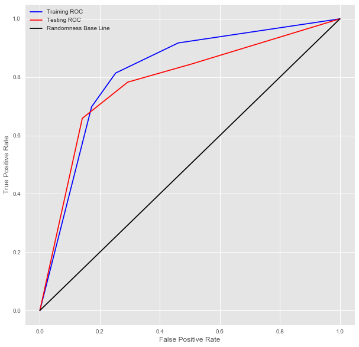

```
AUC TRAIN: 0.8180163283318624
AUC TEST: 0.785059901338971
GINI TRAIN: 0.6360326566637249
GINI TEST: 0.5701198026779419
```

```python
from sklearn.metrics import roc_curve
from sklearn.metrics import roc_auc_score

train_fpr, train_tpr, train_thresholds  = roc_curve(target_train_df['survived'],target_train_df['score'])
test_fpr, test_tpr, test_thresholds  = roc_curve(target_test_df['survived'],target_test_df['score'])

plt.figure(figsize=(10,10))
plt.plot(train_fpr,train_tpr, linestyle='-', color='blue', label='Training ROC')
plt.plot(test_fpr,test_tpr, linestyle='-', color='red', label='Testing ROC')
plt.plot([0,1],[0,1], color='black', label='Randomness Base Line')
plt.xlabel('False Positive Rate')
plt.ylabel('True Positive Rate')
plt.legend()
plt.show()

print('AUC TRAIN:',roc_auc_score(target_train_df['survived'],target_train_df['score']))
print('AUC TEST:',roc_auc_score(target_test_df['survived'],target_test_df['score']))
print('GINI TRAIN:',2*roc_auc_score(target_train_df['survived'],target_train_df['score'])-1)
print('GINI TEST:',2*roc_auc_score(target_test_df['survived'],target_test_df['score'])-1)
```

> **d) Encuentre el threshold en los scores que cae en la rodilla de la curva ROC, con el mismo corte calcular la matriz de confusion, Presicion, Recall, Odds Ratio, F-Score con beta=1.**

Primero rotamos la curva roc 45 grados y la rodilla sera aquella en donde tpr sea máximo

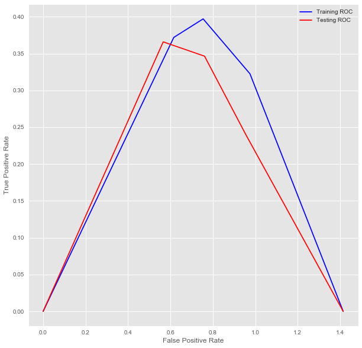

```python
new_train_tpr = [0,0,0,0,0]
new_train_fpr = [0,0,0,0,0]
new_test_tpr = [0,0,0,0,0]
new_test_fpr = [0,0,0,0,0]

for i in range(0,len(train_tpr)):
    new_train_tpr[i]=(train_tpr[i]-train_fpr[i])*(1/pow(2,1/2))
    new_train_fpr[i]=(train_tpr[i]+train_fpr[i])*(1/pow(2,1/2))
    new_test_tpr[i]=(test_tpr[i]-test_fpr[i])*(1/pow(2,1/2))
    new_test_fpr[i]=(test_tpr[i]+test_fpr[i])*(1/pow(2,1/2))

plt.figure(figsize=(10,10))
plt.plot(new_train_fpr,new_train_tpr, linestyle='-', color='blue', label='Training ROC')
plt.plot(new_test_fpr,new_test_tpr, linestyle='-', color='red', label='Testing ROC')
plt.xlabel('False Positive Rate')
plt.ylabel('True Positive Rate')
plt.legend()
plt.show()
```

Nos fijamos en los indices y esos puntos representan el corte

```python
indice=new_train_tpr.index(max(new_train_tpr))

TPR = train_tpr[indice]
FPR = train_fpr[indice]


print("TPR :",TPR)
print("FPR :",FPR)
```

```
TPR : 0.8140495867768595
FPR : 0.2524271844660194
```

### Matriz de confusion

```python
M = [[1-FPR,1-TPR],[FPR,TPR]]
M
```

```
[[0.7475728155339806, 0.18595041322314054],
 [0.2524271844660194, 0.8140495867768595]]
```

### Presicion

```python
Presicion = (1-FPR) / (1-FPR + FPR)
Presicion
```

```
0.7475728155339806
```

### Recall

```python
Recal = TPR / (TPR + 1 - TPR)
Recal
```

```
0.8140495867768596
```

### Odds Ratio

```python
Odds = ((1-FPR)*TPR)/(FPR*(1-TPR))
Odds
```

```
12.96495726495726
```

### F-Score con beta=1

```python
F = (2*(1-FPR)*TPR)/(2*FPR+TPR)
F
```

```
0.9228288973384029
```

# Ejercicio 5:

**Para el dataset de impagos de la tarea 3, realizar el siguiente análisis:**

> **a)Generar nuevas variables con base a las actuales que crea que puedan ayudar al modelo discriminante a clasificar mejor si es que así lo considera conveniente. Incluya una descripción de sus variables en el notebook. Separar el dataset en train y test (50% y 50%), siéntase libre de decidir si debe imputar, escalar, aplicar pca y ohe a las variables del dataset. Se define la variable target como 1 si hay un impago, 0 si no, recuerde no incluir el target dentro de su ingeniería de variables.**

```python
%matplotlib inline
import pandas as pd
import matplotlib.pyplot as plt
import numpy as np
import math
import statsmodels.api as sm
import numpy as np
from sklearn.model_selection import train_test_split
from scipy.stats import norm
import warnings
import seaborn as sns
import random
random.seed(500)
warnings.filterwarnings("ignore")
pd.set_option('max_colwidth',100)
plt.style.use('seaborn-paper')
plt.style.use('seaborn')
```

```python
#Cargar la base de datos
import pandas as pd
loans_raw_df = pd.read_csv('data/loans_payments.csv')

#Quitamos la columna de fechas que de paid-off que no nos sirve
loans_raw_df=loans_raw_df.drop(['paid_off_time'],axis=1)

#Agregar variables
loans_raw_df['deudaxaño'] = (loans_raw_df['Principal']/loans_raw_df['age'])
loans_raw_df['tiempo_venxpeso'] = loans_raw_df['past_due_days']/loans_raw_df['Principal']
loans_raw_df['tiempo_venxaño'] = loans_raw_df['age']/loans_raw_df['terms']

#Definir la variable target
target_dict = {"COLLECTION":1, "COLLECTION_PAIDOFF":0, "PAIDOFF":0 }
loans_raw_df['target'] = loans_raw_df['loan_status'].map(target_dict)
```

```python
from sklearn.model_selection import train_test_split
import pandas as pd
import numpy as np
import seaborn as sns
import matplotlib.pyplot as plt
plt.style.use('ggplot')
%matplotlib inline

def compute_frequencies(dataset_df,col,index=None):
    if index is None:
        index = 'index'
    columns=[col,'freqs_'+col,'relative_freqs_'+col]
    freqs_df = dataset_df.reset_index()\
                .groupby(col)\
                .count()\
                .reset_index()[[index,col]]\
                .rename(columns={index:'freqs_'+col})

    freqs_df['relative_freqs_'+col] = freqs_df['freqs_'+col]/len(loans_raw_df)
    freqs_df= freqs_df[columns].sort_values(col)
    missings_counts = loans_raw_df[col].isna().sum()
    missings_df = pd.DataFrame([['Missings',missings_counts,missings_counts/len(loans_raw_df)]],columns=columns)
    freqs_df = pd.concat([freqs_df, missings_df])
    return freqs_df
```

```python
categoricals = ['Gender','education','loan_status','effective_date','terms','due_date']
```

```python
%matplotlib inline
from sklearn.model_selection import train_test_split
import pandas as pd
import numpy as np
import seaborn as sns
import matplotlib.pyplot as plt
plt.style.use('ggplot')
from sklearn.tree import DecisionTreeClassifier, plot_tree

map_dictionary = {}
for col in categoricals:
    freqs_df = compute_frequencies(loans_raw_df,col,index='Loan_ID')
    display(freqs_df)
    colum_values = list(freqs_df[col])[:len(freqs_df)-1]
    column_dict = {}
    for i,value in enumerate(colum_values):
        column_dict.update({value:str(int(i))})
    column_dict.update({np.nan:np.nan})
    map_dictionary.update({col:column_dict})
loans_cleaned_df = loans_raw_df.replace(map_dictionary).copy()

loans_cleaned_df
```

|  | Gender | freqs_Gender | relative_freqs_Gender |
| --- | --- | --- | --- |
| 0 | female | 77 | 0.154 |
| 1 | male | 423 | 0.846 |
| 0 | Missings | 0 | 0.000 |

|  | education | freqs_education | relative_freqs_education |
| --- | --- | --- | --- |
| 0 | Bechalor | 67 | 0.134 |
| 1 | High School or Below | 209 | 0.418 |
| 2 | Master or Above | 4 | 0.008 |
| 3 | college | 220 | 0.440 |
| 0 | Missings | 0 | 0.000 |

|  | loan_status | freqs_loan_status | relative_freqs_loan_status |
| --- | --- | --- | --- |
| 0 | COLLECTION | 100 | 0.2 |
| 1 | COLLECTION_PAIDOFF | 100 | 0.2 |
| 2 | PAIDOFF | 300 | 0.6 |
| 0 | Missings | 0 | 0.0 |

|  | effective_date | freqs_effective_date | relative_freqs_effective_date |
| --- | --- | --- | --- |
| 0 | 9/10/2016 | 46 | 0.092 |
| 1 | 9/11/2016 | 231 | 0.462 |
| 2 | 9/12/2016 | 148 | 0.296 |
| ... | ... | ... | ... |
| 5 | 9/8/2016 | 4 | 0.008 |
| 6 | 9/9/2016 | 15 | 0.030 |
| 0 | Missings | 0 | 0.000 |

8 rows × 3 columns

|  | terms | freqs_terms | relative_freqs_terms |
| --- | --- | --- | --- |
| 0 | 7 | 21 | 0.042 |
| 1 | 15 | 207 | 0.414 |
| 2 | 30 | 272 | 0.544 |
| 0 | Missings | 0 | 0.000 |

|  | due_date | freqs_due_date | relative_freqs_due_date |
| --- | --- | --- | --- |
| 0 | 10/10/2016 | 123 | 0.246 |
| 1 | 10/11/2016 | 69 | 0.138 |
| 2 | 10/12/2016 | 8 | 0.016 |
| ... | ... | ... | ... |
| 23 | 9/27/2016 | 12 | 0.024 |
| 24 | 9/28/2016 | 10 | 0.020 |
| 0 | Missings | 0 | 0.000 |

26 rows × 3 columns

|  | Loan_ID | loan_status | Principal | terms | effective_date | due_date | past_due_days | age | education | Gender | deudaxaño | tiempo_venxpeso | tiempo_venxaño | target |
| --- | --- | --- | --- | --- | --- | --- | --- | --- | --- | --- | --- | --- | --- | --- |
| 0 | xqd20166231 | 2 | 1000 | 2 | 5 | 6 | NaN | 45 | 1 | 1 | 22.222222 | NaN | 1.500000 | 0 |
| 1 | xqd20168902 | 2 | 1000 | 2 | 5 | 6 | NaN | 50 | 0 | 0 | 20.000000 | NaN | 1.666667 | 0 |
| 2 | xqd20160003 | 2 | 1000 | 2 | 5 | 6 | NaN | 33 | 0 | 0 | 30.303030 | NaN | 1.100000 | 0 |
| ... | ... | ... | ... | ... | ... | ... | ... | ... | ... | ... | ... | ... | ... | ... |
| 497 | xqd20160498 | 1 | 800 | 1 | 2 | 22 | 3.0 | 30 | 3 | 1 | 26.666667 | 0.00375 | 2.000000 | 0 |
| 498 | xqd20160499 | 1 | 1000 | 2 | 2 | 9 | 1.0 | 38 | 3 | 0 | 26.315789 | 0.00100 | 1.266667 | 0 |
| 499 | xqd20160500 | 1 | 1000 | 2 | 2 | 1 | 8.0 | 28 | 1 | 1 | 35.714286 | 0.00800 | 0.933333 | 0 |

500 rows × 14 columns

```python
#Redefinimos ahora la vraiable due_date como numerica
categoricals = ['Gender','education','loan_status','effective_date','terms']

#Definimos las variable numericas
numericals = ['Principal','past_due_days','age','deudaxaño','tiempo_venxaño','tiempo_venxpeso']
loans_cleaned_df = loans_raw_df.replace(map_dictionary).copy()

for col in numericals:
    loans_cleaned_df[col] = loans_raw_df.apply(lambda row: float(row[col]),axis=1)

loans_cleaned_df
```

|  | Loan_ID | loan_status | Principal | terms | effective_date | due_date | past_due_days | age | education | Gender | deudaxaño | tiempo_venxpeso | tiempo_venxaño | target |
| --- | --- | --- | --- | --- | --- | --- | --- | --- | --- | --- | --- | --- | --- | --- |
| 0 | xqd20166231 | 2 | 1000.0 | 2 | 5 | 6 | NaN | 45.0 | 1 | 1 | 22.222222 | NaN | 1.500000 | 0 |
| 1 | xqd20168902 | 2 | 1000.0 | 2 | 5 | 6 | NaN | 50.0 | 0 | 0 | 20.000000 | NaN | 1.666667 | 0 |
| 2 | xqd20160003 | 2 | 1000.0 | 2 | 5 | 6 | NaN | 33.0 | 0 | 0 | 30.303030 | NaN | 1.100000 | 0 |
| ... | ... | ... | ... | ... | ... | ... | ... | ... | ... | ... | ... | ... | ... | ... |
| 497 | xqd20160498 | 1 | 800.0 | 1 | 2 | 22 | 3.0 | 30.0 | 3 | 1 | 26.666667 | 0.00375 | 2.000000 | 0 |
| 498 | xqd20160499 | 1 | 1000.0 | 2 | 2 | 9 | 1.0 | 38.0 | 3 | 0 | 26.315789 | 0.00100 | 1.266667 | 0 |
| 499 | xqd20160500 | 1 | 1000.0 | 2 | 2 | 1 | 8.0 | 28.0 | 1 | 1 | 35.714286 | 0.00800 | 0.933333 | 0 |

500 rows × 14 columns

```python
for col in numericals:
    loans_cleaned_df[col] = loans_cleaned_df.apply(lambda row: np.log(float(row[col])+1),axis=1)

loans_cleaned_df.set_index('Loan_ID',inplace=True)
loans_cleaned_df[:]
```

| Loan_ID | loan_status | Principal | terms | effective_date | due_date | past_due_days | age | education | Gender | deudaxaño | tiempo_venxpeso | tiempo_venxaño | target |
| --- | --- | --- | --- | --- | --- | --- | --- | --- | --- | --- | --- | --- | --- |
| xqd20166231 | 2 | 6.908755 | 2 | 5 | 6 | NaN | 3.828641 | 1 | 1 | 3.145110 | NaN | 0.916291 | 0 |
| xqd20168902 | 2 | 6.908755 | 2 | 5 | 6 | NaN | 3.931826 | 0 | 0 | 3.044522 | NaN | 0.980829 | 0 |
| xqd20160003 | 2 | 6.908755 | 2 | 5 | 6 | NaN | 3.526361 | 0 | 0 | 3.443715 | NaN | 0.741937 | 0 |
| ... | ... | ... | ... | ... | ... | ... | ... | ... | ... | ... | ... | ... | ... |
| xqd20160498 | 1 | 6.685861 | 1 | 2 | 22 | 1.386294 | 3.433987 | 3 | 1 | 3.320228 | 0.003743 | 1.098612 | 0 |
| xqd20160499 | 1 | 6.908755 | 2 | 2 | 9 | 0.693147 | 3.663562 | 3 | 0 | 3.307465 | 0.001000 | 0.818310 | 0 |
| xqd20160500 | 1 | 6.908755 | 2 | 2 | 1 | 2.197225 | 3.367296 | 1 | 1 | 3.603166 | 0.007968 | 0.659246 | 0 |

500 rows × 13 columns

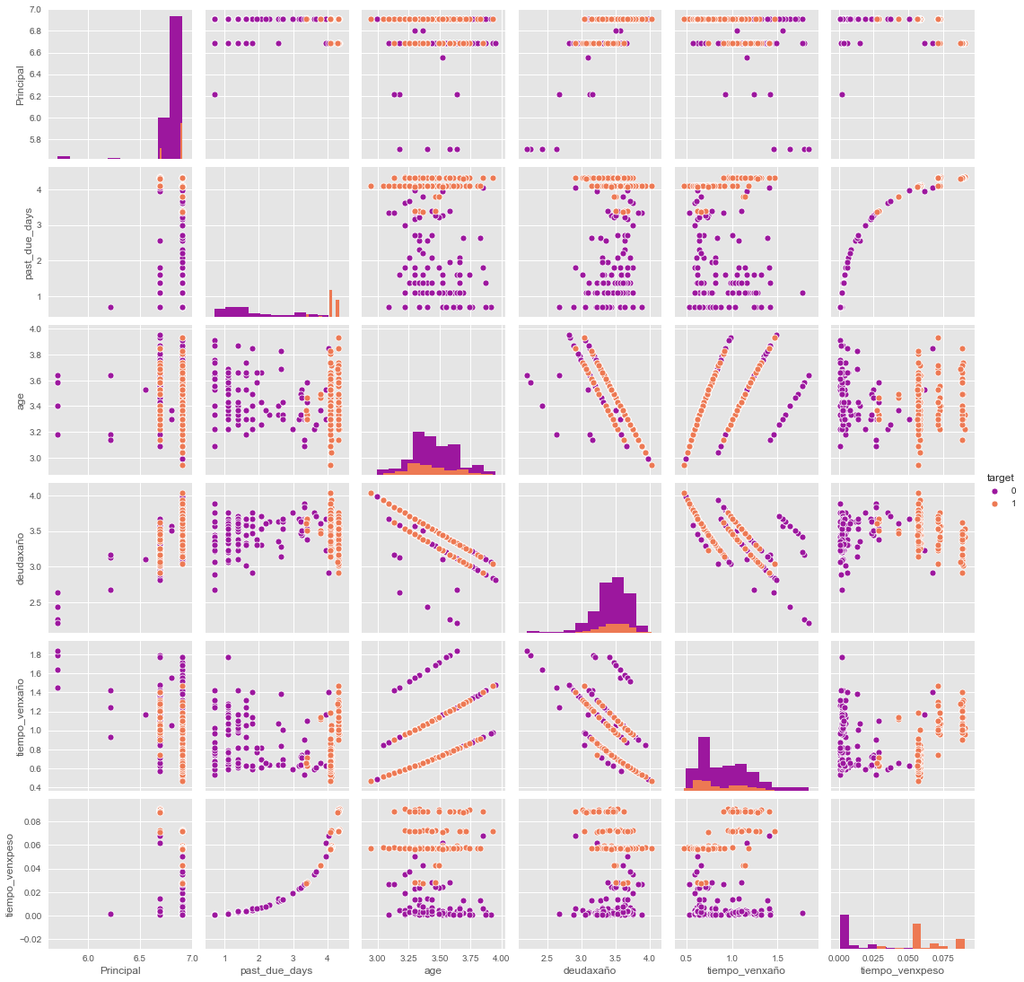

```python
import seaborn as sns
smp = sns.pairplot(loans_cleaned_df[numericals+['target']],hue="target",diag_kind='hist',palette="plasma")
```

```python
from sklearn.impute import SimpleImputer
imputer_cat = SimpleImputer(missing_values=np.nan, strategy='most_frequent').fit(loans_cleaned_df[categoricals])
imputer_cont = SimpleImputer(missing_values=np.nan, strategy='mean').fit(loans_cleaned_df[numericals])

imputed_cat_X = imputer_cat.transform(loans_cleaned_df[categoricals])
imputed_cont_X = imputer_cont.transform(loans_cleaned_df[numericals])

imputed_cat_df = pd.DataFrame(imputed_cat_X,columns=categoricals,index=loans_cleaned_df.index)
imputed_cont_df = pd.DataFrame(imputed_cont_X,columns=numericals,index=loans_cleaned_df.index)
dataset_df = imputed_cat_df.merge(imputed_cont_df,left_index=True, right_index=True)
dataset_df['target'] = loans_cleaned_df['target']

#Dividimos el dataset de acuerdo al target
dataset_1_df = dataset_df[dataset_df['target']==1]
dataset_0_df = dataset_df[dataset_df['target']==0]
```

```python
from sklearn.model_selection import train_test_split
imputed_train_df, imputed_test_df = train_test_split(dataset_df, test_size=0.5)
imputed_train_df.head(10)
```

| Loan_ID | Gender | education | loan_status | effective_date | terms | Principal | past_due_days | age | deudaxaño | tiempo_venxaño | tiempo_venxpeso | target |
| --- | --- | --- | --- | --- | --- | --- | --- | --- | --- | --- | --- | --- |
| xqd20160149 | 1 | 0 | 2 | 2 | 1 | 6.908755 | 2.952947 | 3.295837 | 3.675326 | 1.005522 | 0.037112 | 0 |
| xqd20160045 | 0 | 0 | 2 | 1 | 1 | 6.908755 | 2.952947 | 3.218876 | 3.753418 | 0.955511 | 0.037112 | 0 |
| xqd20160471 | 1 | 1 | 1 | 2 | 1 | 6.908755 | 1.098612 | 3.496508 | 3.473518 | 1.142097 | 0.001998 | 0 |
| ... | ... | ... | ... | ... | ... | ... | ... | ... | ... | ... | ... | ... |
| xqd20160311 | 1 | 3 | 0 | 0 | 2 | 6.908755 | 4.110874 | 3.433987 | 3.536117 | 0.693147 | 0.058269 | 1 |
| xqd20160125 | 1 | 3 | 2 | 1 | 2 | 6.908755 | 2.952947 | 3.526361 | 3.443715 | 0.741937 | 0.037112 | 0 |
| xqd20160024 | 1 | 3 | 2 | 0 | 1 | 6.908755 | 2.952947 | 3.295837 | 3.675326 | 1.005522 | 0.037112 | 0 |

10 rows × 12 columns

> **b) Ajustar un modelo de clasificación sobre el dataset de enetrenamiento. Siéntase libre de escoger el alforitmo a utilizar.**

```python
#Definimos las varaibles numericas que vamos a considerar
features = ['Principal','past_due_days','age','deudaxaño','tiempo_venxaño','tiempo_venxpeso']

train_X = imputed_train_df[features]
train_Y = imputed_train_df[['target']]
test_X = imputed_test_df[features]
test_Y = imputed_test_df[['target']]

sm_model = sm.Logit(train_Y, sm.add_constant(train_X)).fit(disp=0)
display(sm_model.summary())

imputed_train_df['score'] = sm_model.predict(sm.add_constant(train_X)).copy()
imputed_test_df['score'] = sm_model.predict(sm.add_constant(test_X)).copy()
```

Logit Regression Results

| Dep. Variable: | target | No. Observations: | 250 |
| --- | --- | --- | --- |
| Model: | Logit | Df Residuals: | 243 |
| Method: | MLE | Df Model: | 6 |
| Date: | Fri, 19 Jun 2020 | Pseudo R-squ.: | 0.8923 |
| Time: | 08:53:13 | Log-Likelihood: | -13.321 |
| converged: | True | LL-Null: | -123.70 |
| Covariance Type: | nonrobust | LLR p-value: | 7.159e-45 |

|  | coef | std err | z | P>\|z\| | [0.025 | 0.975] |
| --- | --- | --- | --- | --- | --- | --- |
| const | -97.3137 | 162.043 | -0.601 | 0.548 | -414.912 | 220.284 |
| Principal | -109.9793 | 499.619 | -0.220 | 0.826 | -1089.216 | 869.257 |
| past_due_days | 9.2793 | 2.805 | 3.308 | 0.001 | 3.781 | 14.778 |
| age | 118.2043 | 515.403 | 0.229 | 0.819 | -891.967 | 1128.375 |
| deudaxaño | 118.9752 | 515.594 | 0.231 | 0.818 | -891.571 | 1129.521 |
| tiempo_venxaño | -1.2222 | 4.019 | -0.304 | 0.761 | -9.099 | 6.654 |
| tiempo_venxpeso | -48.1228 | 77.243 | -0.623 | 0.533 | -199.516 | 103.271 |

Possibly complete quasi-separation: A fraction 0.18 of observations can be  
perfectly predicted. This might indicate that there is complete  
quasi-separation. In this case some parameters will not be identified.

> **c) Calcular y graficar la curva ROC, el AUC y el índice de GINI con base a los scores generados por el algoritmo sobre el dataset de test. El AUC obtenido debe ser mayor o igual a 0.65 si no lo alcanza la métrica regresar a los pasos anteriores haciendo ajustes a la ingeniería de variables y al algoritmo de clasificación y repetir hasta alcanzar la métrica mínima.**

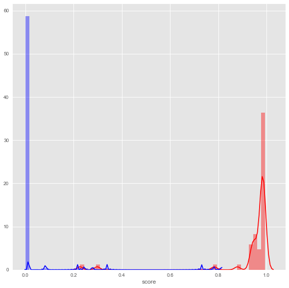

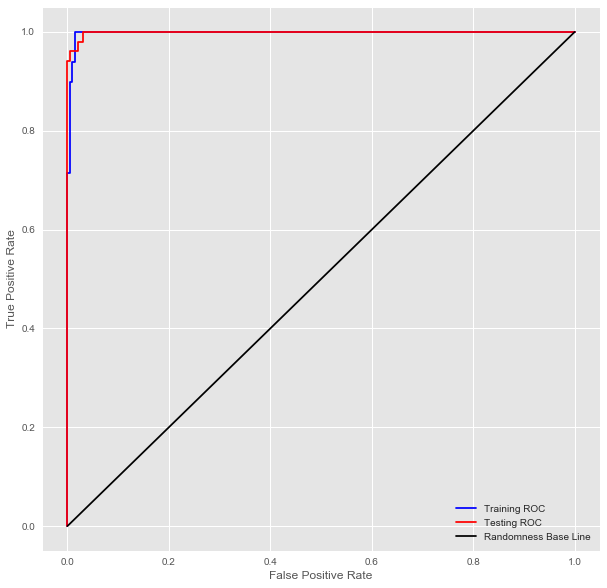

```
AUC TRAIN: 0.9977662706873794
AUC TEST: 0.9989161493743226
GINI TRAIN: 0.9955325413747589
GINI TEST: 0.9978322987486452
```

```python
from sklearn.metrics import roc_curve
from sklearn.metrics import roc_auc_score

train_fpr, train_tpr, train_thresholds  = roc_curve(imputed_train_df['target'],imputed_train_df['score'])
test_fpr, test_tpr, test_thresholds  = roc_curve(imputed_test_df['target'],imputed_test_df['score'])

#plt.figure(figsize=(10,10))
#scatterPlot(plt,dataset_0_df,'x1','x2','Blue',color='Black',alpha=0.6)
#scatterPlot(plt,dataset_1_df,'x1','x2','Red',color='Black',alpha=0.6)

plt.figure(figsize=(10,10))
sns.distplot(imputed_test_df[imputed_test_df['target']==1]['score'], color='red', label='Positives')
sns.distplot(imputed_test_df[imputed_test_df['target']==0]['score'], color='blue', label='Negatives')

plt.figure(figsize=(10,10))
plt.plot(train_fpr,train_tpr, linestyle='-', color='blue', label='Training ROC')
plt.plot(test_fpr,test_tpr, linestyle='-', color='red', label='Testing ROC')
plt.plot([0,1],[0,1], color='black', label='Randomness Base Line')
plt.xlabel('False Positive Rate')
plt.ylabel('True Positive Rate')
plt.legend()
plt.show()

print('AUC TRAIN:',roc_auc_score(imputed_train_df['target'],imputed_train_df['score']))
print('AUC TEST:',roc_auc_score(imputed_test_df['target'],imputed_test_df['score']))
print('GINI TRAIN:',2*roc_auc_score(imputed_train_df['target'],imputed_train_df['score'])-1)
print('GINI TEST:',2*roc_auc_score(imputed_test_df['target'],imputed_test_df['score'])-1)
```

> **d) Se define la ganancia de la siguiente manera: si el target es 0 entonces la ganancia será la diferencia entre el monto prestado con interés y el monto prestado,si el target es un 1 entonces la ganancia sera negativa con severidad igual al monto prestado. Con eso calcule y grafique la curva de rentabilidad,encuentre el punto óptimo de maxima ganancia para encontrar el threshold, finalmente uselo para calcular la matriz de confusión, Presicion, Recall, Odds Ratio, F-Score con beta=1, margen de ganancia, denegaciones y admisiones.**

```python
imputed_test_df.sort_values('score',ascending=True,inplace=True)
imputed_test_df['profit'] = np.where(imputed_test_df['target']==0,imputed_test_df['Principal'],-imputed_test_df['Principal'])
imputed_test_df['cumulated_profit'] = imputed_test_df['profit'].cumsum()
imputed_test_df[imputed_test_df['cumulated_profit'] == imputed_test_df['cumulated_profit'].max()]
```

| Loan_ID | Gender | education | loan_status | effective_date | terms | Principal | past_due_days | age | deudaxaño | tiempo_venxaño | tiempo_venxpeso | target | score | profit | cumulated_profit |
| --- | --- | --- | --- | --- | --- | --- | --- | --- | --- | --- | --- | --- | --- | --- | --- |
| xqd20160457 | 1 | 3 | 1 | 2 | 2 | 6.908755 | 3.663562 | 3.258097 | 3.713572 | 0.606136 | 0.037296 | 0 | 0.780726 | 6.908755 | 1340.505313 |

```
HEAD:
```

| Loan_ID | Gender | education | loan_status | effective_date | terms | Principal | past_due_days | age | deudaxaño | tiempo_venxaño | tiempo_venxpeso | target | score | profit | cumulated_profit | target_est |
| --- | --- | --- | --- | --- | --- | --- | --- | --- | --- | --- | --- | --- | --- | --- | --- | --- |
| xqd20160430 | 1 | 0 | 1 | 1 | 1 | 6.216606 | 0.693147 | 3.637586 | 2.675080 | 1.243194 | 0.001998 | 0 | 7.276534e-13 | 6.216606 | 6.216606 | 0 |
| xqd20160468 | 1 | 1 | 1 | 2 | 1 | 6.908755 | 0.693147 | 3.737670 | 3.234365 | 1.317301 | 0.001000 | 0 | 6.611548e-12 | 6.908755 | 13.125361 | 0 |
| xqd20169083 | 1 | 3 | 1 | 1 | 1 | 6.908755 | 0.693147 | 3.663562 | 3.307465 | 1.262242 | 0.001000 | 0 | 6.641272e-12 | 6.908755 | 20.034116 | 0 |
| xqd20160465 | 0 | 1 | 1 | 2 | 2 | 6.908755 | 0.693147 | 3.761200 | 3.211228 | 0.875469 | 0.001000 | 0 | 1.167487e-11 | 6.908755 | 26.942870 | 0 |
| xqd20160427 | 1 | 3 | 1 | 1 | 2 | 6.908755 | 0.693147 | 3.526361 | 3.443715 | 0.741937 | 0.001000 | 0 | 1.245108e-11 | 6.908755 | 33.851625 | 0 |

```
TAIL:
```

| Loan_ID | Gender | education | loan_status | effective_date | terms | Principal | past_due_days | age | deudaxaño | tiempo_venxaño | tiempo_venxpeso | target | score | profit | cumulated_profit | target_est |
| --- | --- | --- | --- | --- | --- | --- | --- | --- | --- | --- | --- | --- | --- | --- | --- | --- |
| xqd20160319 | 1 | 0 | 0 | 0 | 2 | 6.908755 | 4.110874 | 3.135494 | 3.838474 | 0.550046 | 0.058269 | 1 | 0.992218 | -6.908755 | 1038.971935 | 1 |
| xqd20160301 | 1 | 3 | 0 | 6 | 1 | 6.908755 | 4.343805 | 3.401197 | 3.569047 | 1.076139 | 0.073250 | 1 | 0.993292 | -6.908755 | 1032.063180 | 1 |
| xqd20160339 | 0 | 3 | 0 | 1 | 1 | 6.908755 | 4.317488 | 3.332205 | 3.638560 | 1.029619 | 0.071390 | 1 | 0.993406 | -6.908755 | 1025.154425 | 1 |
| xqd20160364 | 1 | 3 | 0 | 1 | 1 | 6.908755 | 4.317488 | 3.295837 | 3.675326 | 1.005522 | 0.071390 | 1 | 0.994059 | -6.908755 | 1018.245671 | 1 |
| xqd20160352 | 1 | 3 | 0 | 1 | 1 | 6.908755 | 4.317488 | 3.258097 | 3.713572 | 0.980829 | 0.071390 | 1 | 0.994724 | -6.908755 | 1011.336916 | 1 |

```
OPTIMAL THRESHOLD CUTOFF SCORE VALUE:
```

| Loan_ID | Gender | education | loan_status | effective_date | terms | Principal | past_due_days | age | deudaxaño | tiempo_venxaño | tiempo_venxpeso | target | score | profit | cumulated_profit |
| --- | --- | --- | --- | --- | --- | --- | --- | --- | --- | --- | --- | --- | --- | --- | --- |
| xqd20160457 | 1 | 3 | 1 | 2 | 2 | 6.908755 | 3.663562 | 3.258097 | 3.713572 | 0.606136 | 0.037296 | 0 | 0.780726 | 6.908755 | 1340.505313 |

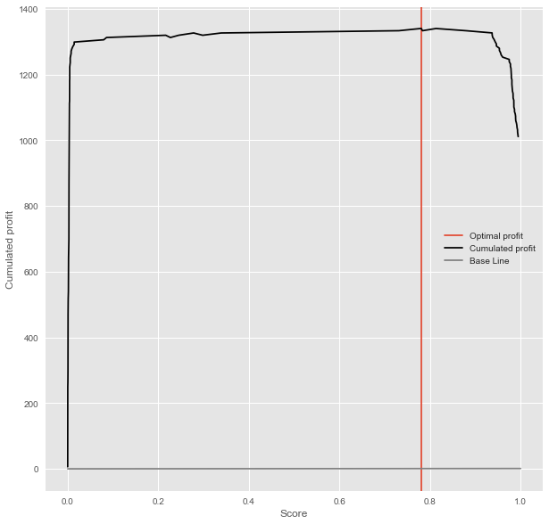

```
PRECISION: 0.9607843137254902
RECALL: 0.9607843137254902
F-SCORE: 0.9607843137254902
ACCURACY: 0.984
DENIED OPERATIONS: 51
DENIED PERCENTAGE: 0.204
ADMISSIONS OPERATIONS: 200
ADMISSIONS PERCENTAGE: 0.8
```

```python
from sklearn.metrics import  confusion_matrix, precision_score, recall_score, f1_score, accuracy_score

imputed_test_df.sort_values('score',ascending=True,inplace=True)
imputed_test_df['profit'] = np.where(imputed_test_df['target']==0,imputed_test_df['Principal'],-imputed_test_df['Principal'])
imputed_test_df['cumulated_profit'] = imputed_test_df['profit'].cumsum()
threshold_row = imputed_test_df[imputed_test_df['cumulated_profit'] ==imputed_test_df['cumulated_profit'].max()]
threshold_cutoff = threshold_row['score'].values[0]
imputed_test_df['target_est'] = np.where(imputed_test_df['score']>=threshold_cutoff,1,0)

precision = precision_score(imputed_test_df['target'],imputed_test_df['target_est'])
recall = recall_score(imputed_test_df['target'],imputed_test_df['target_est'])
f1 = f1_score(imputed_test_df['target'],imputed_test_df['target_est'])
accuracy = accuracy_score(imputed_test_df['target'],imputed_test_df['target_est'])

print('HEAD:')
display(imputed_test_df.head(5))
print('TAIL:')
display(imputed_test_df.tail(5))
print('OPTIMAL THRESHOLD CUTOFF SCORE VALUE:')
display(threshold_row)

plt.figure(figsize=(10,10))
plt.axvline(x=threshold_cutoff,label='Optimal profit')
plt.plot(imputed_test_df['score'].values,imputed_test_df['cumulated_profit'].values, linestyle='-', color='Black', label='Cumulated profit')
plt.plot([1,0],[1,0], linestyle='-', color='Gray', label='Base Line')

plt.xlabel('Score')
plt.ylabel('Cumulated profit')
plt.legend()
plt.show()

print('PRECISION:',precision)
print('RECALL:',recall)
print('F-SCORE:',f1)
print('ACCURACY:',accuracy)
print('DENIED OPERATIONS:',len(imputed_test_df[imputed_test_df['score']>=threshold_cutoff]))
print('DENIED PERCENTAGE:',len(imputed_test_df[imputed_test_df['score']>=threshold_cutoff])/len(imputed_test_df))
print('ADMISSIONS OPERATIONS:',len(imputed_test_df[imputed_test_df['score']<=threshold_cutoff]))
print('ADMISSIONS PERCENTAGE:',len(imputed_test_df[imputed_test_df['score']<=threshold_cutoff])/len(imputed_test_df))
```

### Odds Ratio

```python
(precision*recall)/(0.01463414663*0.04444444)
```

```
1419.276353851967
```

### Matriz de confusión

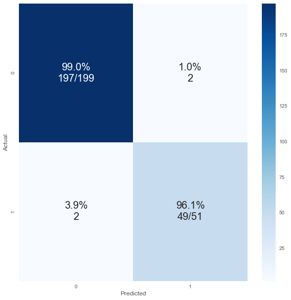

```python
from sklearn.metrics import  confusion_matrix
plot_confusion_matrix(plt,imputed_test_df['target'],imputed_test_df['target_est'],figsize=(10,10),font_size=20)
```